# Projekt z przedmiotu Analiza Historii Zdarzeń

Marcel Gęsicki (282631), Jan Jarosz (261151), Paweł Kawecki (282639), Wojciech Sobczuk (261172)

# Wprowadzenie, eksploracyjna analiza danych

Badany w niniejszym opracowaniu zbiór danych składa się z danych medycznych odnoszących się do wyników koagulacji laserowej w leczeniu ratinopatii cukrzycowej. Samo schorzenie spowodowane jest uszkodzeniem naczyń krwionośnych siatkówki oka. W celu wyleczenia schorzenia używana jest laseroterapia siatkówki. W niniejszej pracy analizowany przez nas będzie czas przeżycia w kontekście utraty ostrości wzroku oraz wpływu danych zmiennych na spowolnienie tego procesu. Zbiór danych składa się z następujących zmiennych

- **id**: Odnosi się do indywidualnego numeru badanej jednostki. W grupie badawczej jest 197 indywidualnych jednostek.
- **laser**: typ zastosowanego rozwiązania laserowego w leczeniu. Zmienna zawiera dwa warianty - Xenon oraz argon.
- **age**: Wiek pacjenta w chwili wykrycia schorzenia.
- **eye**: Badane oko. Warianty to “left” oraz “right”
- **trt**: Zmienna dychtomiczna odnosząca się do leczenia. 0 = brak leczenia, 1 = leczenie laserowe.
- **risk**: Grupy ryzyka w skali 6-12.
- **time**: Czas w miesiącach do wystąpienia zdarzenia utraty wzroku, bądź ostatnia zaobserwowana obserwacja.
- **status**: Status badanego w postaci dychotomicznej. 0 = ocenzurowane, 1 = utrata wzroku przez badaną jednostkę.

Analizę rozpoczniemy od zagłębienia się w dane i dokonania transformacji, jeśli takowa będzie potrzebna.

```r
diabetic <- survival::diabetic


summary(diabetic)
```

```
##        id           laser          age           eye           trt
##  Min.   :   5.0   xenon:228   Min.   : 1.00   left :197   Min.   :0.0
##  1st Qu.: 480.0   argon:166   1st Qu.:10.00   right:197   1st Qu.:0.0
##  Median : 834.0               Median :16.00               Median :0.5
##  Mean   : 873.2               Mean   :20.78               Mean   :0.5
##  3rd Qu.:1296.0               3rd Qu.:30.00               3rd Qu.:1.0
##  Max.   :1749.0               Max.   :58.00               Max.   :1.0
##       risk             time           status
##  Min.   : 6.000   Min.   : 0.30   Min.   :0.0000
##  1st Qu.: 9.000   1st Qu.:13.98   1st Qu.:0.0000
##  Median :10.000   Median :38.80   Median :0.0000
##  Mean   : 9.698   Mean   :35.58   Mean   :0.3934
##  3rd Qu.:11.000   3rd Qu.:54.25   3rd Qu.:1.0000
##  Max.   :12.000   Max.   :74.97   Max.   :1.0000
```

Powyżej widoczne jest wstępne podsumowanie zmiennych zawartych w rozpatrywanym przez nas zbiorze danych. Widać, że w zbiorze danych nie występują wartości NA oznaczające brak danych. R zinterpretował zmienne `trt` oraz `risk` jako zmienne numeryczne, jednakże są to zmienne jakościowe (typu factor). Poniższy kod kategoryzuje zmienne.

```r
diabetic <- diabetic %>%
  mutate(trt = as.factor(as.character(trt)),
         risk = as.factor(risk),
         status = as.factor(status))
```

Następnie zwizualizowane zostaną rozkłady zmiennych ze zbioru.

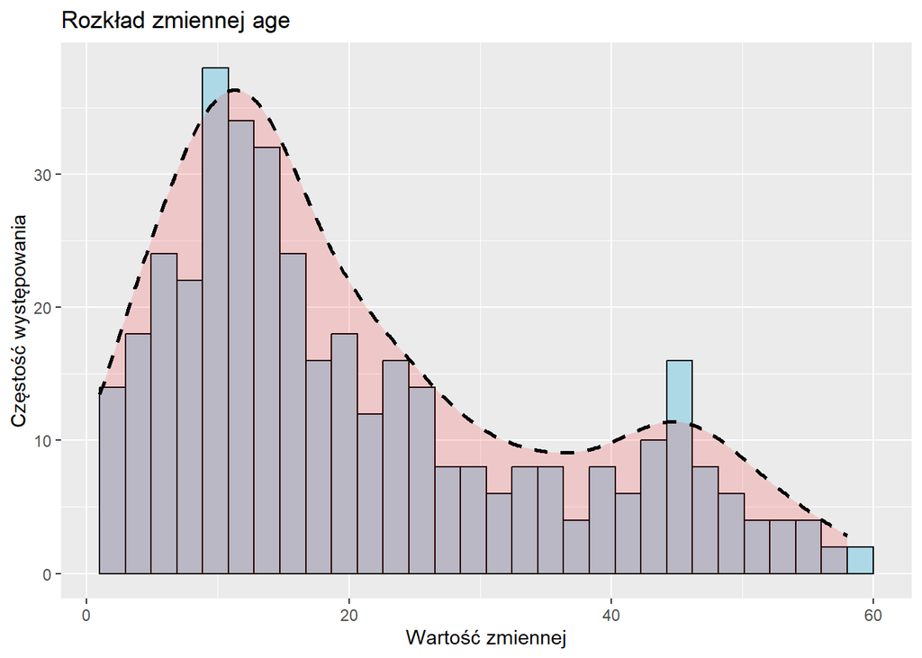

```r
age <- diabetic %>% dplyr::select(c(age))
df_age <- data.frame(age)

ggplot(df_age, aes(x=age))+
    geom_histogram(colour = 1,
                   fill = "lightblue",
                   bins=30) +
  ggtitle("Rozkład zmiennej age")+
  ylab("Częstość występowania")+
  xlab("Wartość zmiennej")+
  geom_density(aes(y = ..density.. *1000),
               lwd = 1,
               linetype = 2,
               colour= 1,
               fill = 'red',
               alpha = 0.15)
```

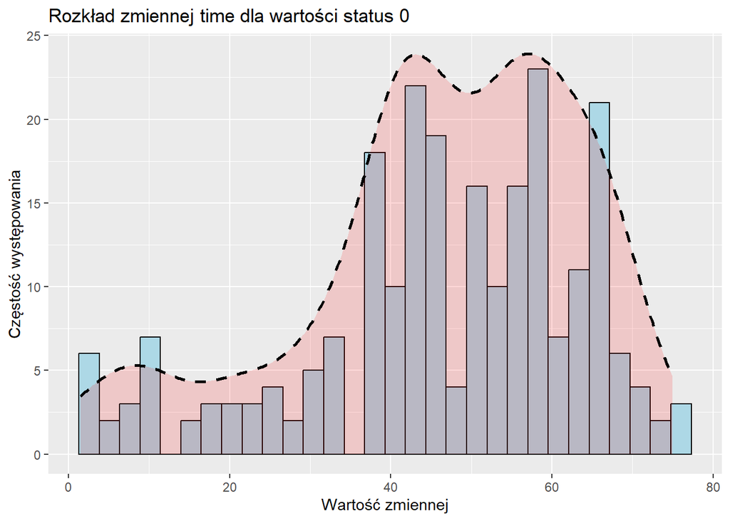

```r
time <- diabetic %>% dplyr::filter(status==0) %>% dplyr::select(c(time))
df_time_nostatus <- data.frame(time)

ggplot(df_time_nostatus, aes(x=time))+
    geom_histogram(colour = 1,
                   fill = "lightblue",
                   bins=30) +
  ggtitle("Rozkład zmiennej time dla wartości status 0")+
  ylab("Częstość występowania")+
  xlab("Wartość zmiennej")+
  geom_density(aes(y = ..density.. *1000),
               lwd = 1,
               linetype = 2,
               colour= 1,
               fill = 'red',
               alpha = 0.15)
```

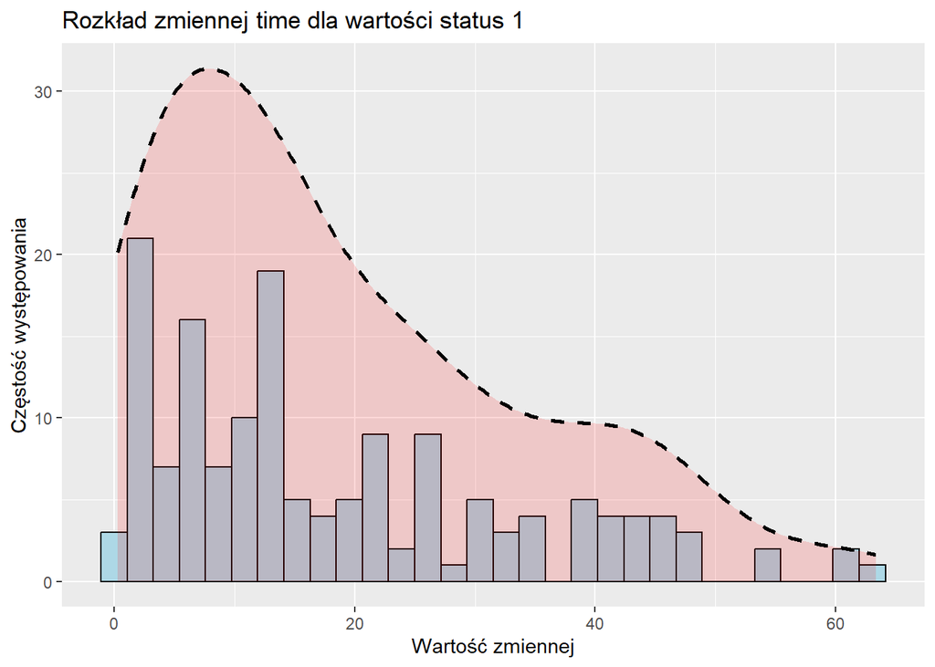

```r
time <- diabetic %>% dplyr::filter(status==1) %>% dplyr::select(c(time))
df_time_status <- data.frame(time)

ggplot(df_time_status, aes(x=time))+
    geom_histogram(colour = 1,
                   fill = "lightblue",
                   bins=30) +
  ggtitle("Rozkład zmiennej time dla wartości status 1")+
  ylab("Częstość występowania")+
  xlab("Wartość zmiennej")+
  geom_density(aes(y = ..density.. *1000),
               lwd = 1,
               linetype = 2,
               colour= 1,
               fill = 'red',
               alpha = 0.15)
```

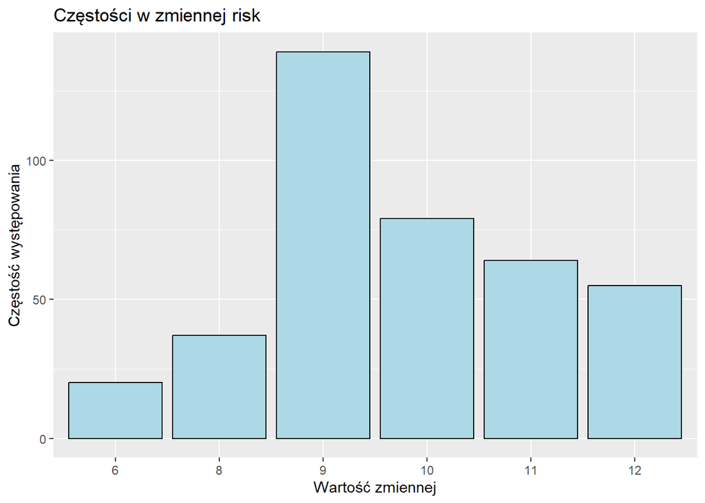

```r
risk <- diabetic %>% dplyr::select(c(risk))
df_risk <- data.frame(risk)

ggplot(df_risk, aes(x=risk))+
    geom_bar(colour = 1,
                   fill = "lightblue") +
  ggtitle("Częstości w zmiennej risk")+
  ylab("Częstość występowania")+
  xlab("Wartość zmiennej")
```

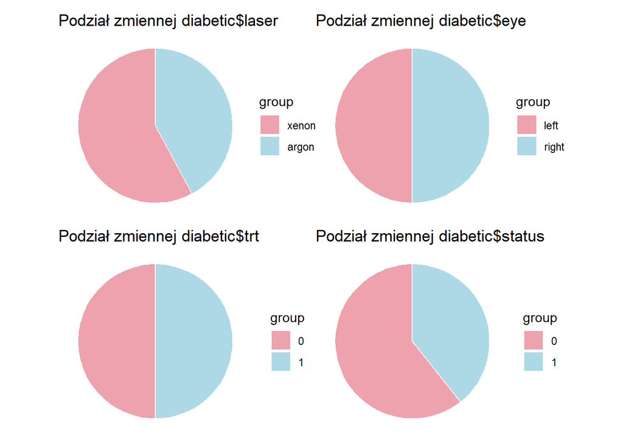

```r
generate_pie <- function(column){
  name <- deparse(substitute(column))
  df <- data.frame(column)
  agg <- df %>% count(df[,1]) %>% as.data.frame()
  colnames(agg)[1] <- 'group'
  p1 <- ggplot(agg, aes(x = "", y=n, fill=group)) +
    geom_bar(stat = 'identity', width = 1, color='white')+
    ggtitle(glue("Podział zmiennej {name}"))+
    coord_polar('y', start=0)+
    scale_fill_manual(values=c("lightpink2", 'lightblue'))+
    theme_void()

  return(p1)
}

p_1 <- generate_pie(diabetic$laser)
p_2 <- generate_pie(diabetic$eye)
p_3 <- generate_pie(diabetic$trt)
p_4<- generate_pie(diabetic$status)

p_1 + p_2 + p_3 + p_4
```

```r
diabetic <- diabetic %>%
  mutate(status = as.numeric(status))
```

Pierwsza dwa histogramy przedstawiają rozkład wartości w zmiennych **age** oraz **time**. Zauważyć możemy, iż duża liczba pacjentów ze zdiagnozowaną chorbą znajduje się pomiędzy 8 a 20 rokiem życia. Wiek około 45 lat skupia wokół siebie sporo pacjentów z grupy osób dorosłych. Najmniej zdiagnozowano osób w wieku powyżej 55 lat. Poniżej widoczny jest wykres częstotliowści liczby miesięcy do momentu utraty wzroku, w podziale na pacjentów ocenzurowanych oraz tych, który utracili wzrok. Najczęstszymi wartościami ocenzurowanymi czasu to od 38 do 66 miesięcy od diagnozy. Rozkład zmiennej czasowej dla pacjentów, którzy utracili wzrok skupia się bliżej pirewszych miesięcy.

Kolejny analizowany powyżej wykres prezentuje rozkład częstości występowania danej grupy ryzyka (**risk**). Widać, że najczęściej przypisywana jest wartość 9 oraz 10. Najrzadszą wartością są grupy ryzyka na poziomie 6 oraz 8.

Kolejne wykresy przedstawiają podział zbiorów **eye**, **laser**, **status** oraz **trt**. W przypadku zmiennej eye mamy równą taką samą liczbę obserwacji dla prawego i lewego oka. Częściej w leczeniu stosowany jest typ lasera xenonowego, niż argonowego. Następna prezentowana na wykresie zmienna to trt. W tym przypadku mamy równą liczbę obserwacji z zastosowaniem i nie zastosowaniem leczenia. W ostatniej prezentowanej zmiennej, czyli status, przeważająca jest liczba danych cenzurowanych (239), niż utraty wzroku (155).

# Wstępna analiza utraty wzroku

Analizę rozpoczniemy od estymacji krzywej prawdopodobieństwa zachowania wzroku w stosunku do czasu przy użyciu estymatorów Kaplana-Meiera oraz Nelsona-Aalena. Przerywanymi liniami zaznaczony został 95% przedział ufności tych estymatorów.

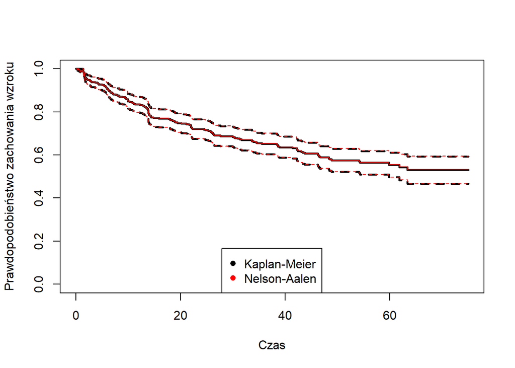

```r
mod.1 <- survfit(Surv(time, status) ~ 1, conf.type="plain", data=diabetic)
mod.2 <- survfit(Surv(time, status) ~ 1, conf.type="plain", type="fleming-harrington", data=diabetic)

plot(mod.1, xlab="Czas", ylab="Prawdopodobieństwo zachowania wzroku", col = 'black', pch=16, lwd = 2.5)
lines(mod.2, col="red", pch=16)
legend(x = 'bottom', legend = c('Kaplan-Meier','Nelson-Aalen'), col = c('black','red'), pch=16)
```

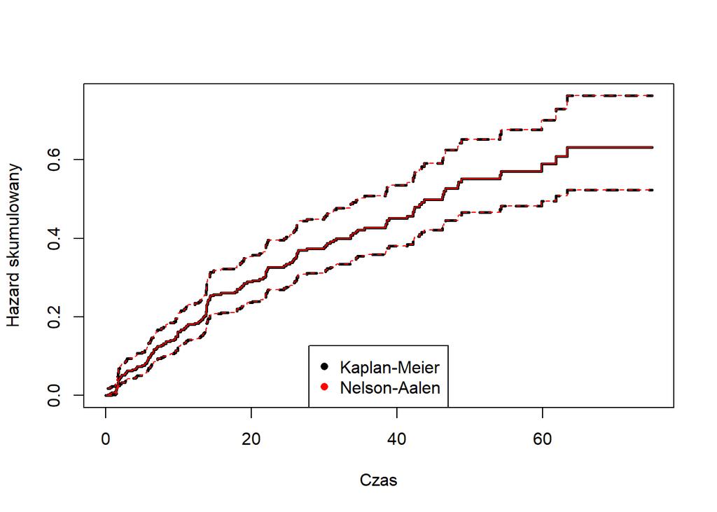

```r
plot(mod.1, fun="cumhaz", xlab="Czas", ylab="Hazard skumulowany", col = 'black', lwd = 2.5)
lines(mod.2, fun="cumhaz", col="red")
legend(x = 'bottom', legend = c('Kaplan-Meier','Nelson-Aalen'), col = c('black','red'), pch=16)
```

```r
rm(mod.1)
rm(mod.2)
```

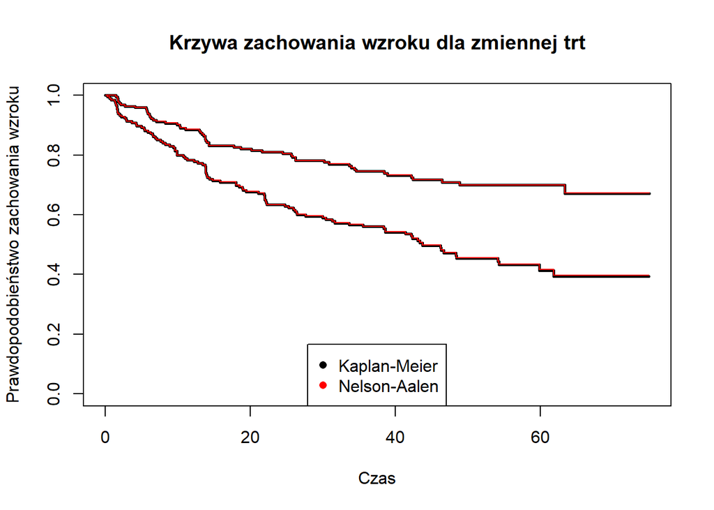

```r
mod.km.trt <- survfit(Surv(time, status) ~ trt, conf.type="plain", data=diabetic)
mod.na.trt <- survfit(Surv(time, status) ~ trt, conf.type="plain", data=diabetic, type="fleming-harrington")



plot(mod.km.trt, xlab="Czas", ylab="Prawdopodobieństwo zachowania wzroku", col = 'black', lwd = 2.5, main="Krzywa zachowania wzroku dla zmiennej trt")
lines(mod.na.trt, col="red")
legend(x = 'bottom', legend = c('Kaplan-Meier','Nelson-Aalen'), col = c('black','red'), pch=16)
```

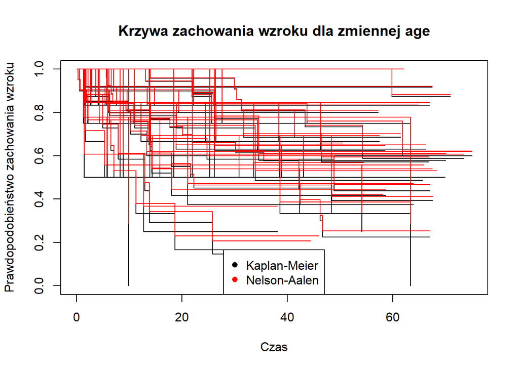

```r
mod.km.age <- survfit(Surv(time, status) ~ age, conf.type="plain", data=diabetic)
mod.na.age <- survfit(Surv(time, status) ~ age, conf.type="plain", data=diabetic, type="fleming-harrington")

plot(mod.km.age, xlab="Czas", ylab="Prawdopodobieństwo zachowania wzroku", col = 'black', main="Krzywa zachowania wzroku dla zmiennej age")
lines(mod.na.age, col="red")
legend(x = 'bottom', legend = c('Kaplan-Meier','Nelson-Aalen'), col = c('black','red'), pch=16)
```

**Krzywa zachowania wzroku zmiennej trt** Powyżej przedstawione zostały wykresy prawdopodobieństwa zachowania wzroku z wykorzystaniem estymatora Kaplana-Meiera oraz Nelsona-Aalena. Widzimy w przypadku krzywej zachowania wzroku dla zmiennej **trt**, że prawdopodobeństwo zachowania wzroku stopniowo maleje. Wartości obu estymatorów są bardzo podobno co potwierdza fakt, że obie linie się nakładają w obrębie grup.

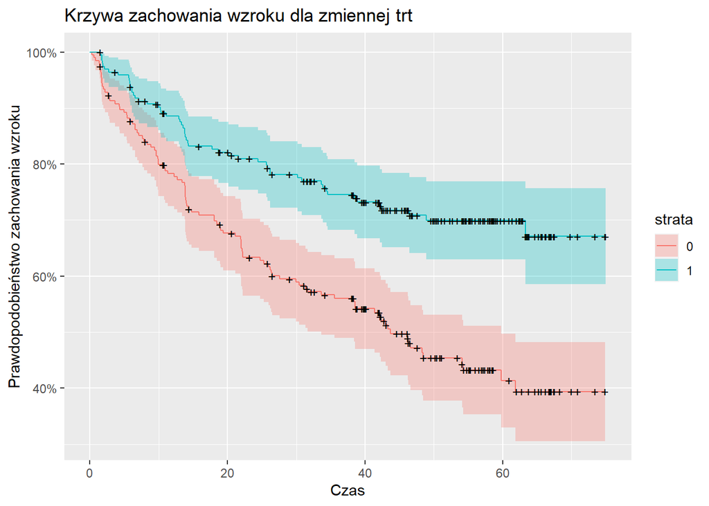

```r
autoplot(mod.km.trt, xlab="Czas", ylab="Prawdopodobieństwo zachowania wzroku", main = "Krzywa zachowania wzroku dla zmiennej trt")
```

Zauważyć można jednak duży rozstrzał w prawdopodobieństwach zachowania wzroku dla grup z terapią oraz bez niej. Zostanie to głębiej zbadane w dalszej części pracy.

**Krzywa zachowania wzroku zmiennej age** Ze względu na dość chaotyczny wygląd wykresu dla zmiennej age, zdecydowaliśmy się na faktoryzację tej zmiennej poprzez podział kwantylowy. W normalnej postaci interpretacja wykresu jest bardzo niepraktyczna. Poniżej znajdują się wykresy z estymatorami K-M oraz N-A dla tej zmiennej.

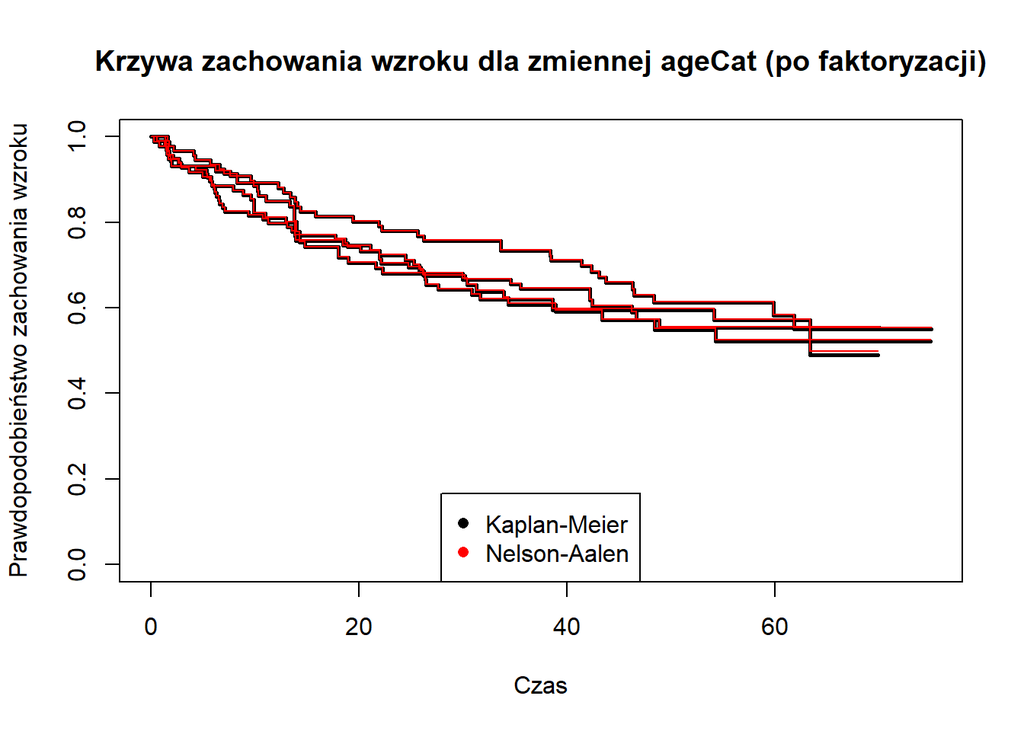

```r
diabetic$ageCat <- quantcut(diabetic$age,q=4)

mod.km.ageCat <- survfit(Surv(time, status) ~ ageCat, conf.type="plain", data=diabetic)
mod.na.ageCat <- survfit(Surv(time, status) ~ ageCat, conf.type="plain", data=diabetic, type="fleming-harrington")

plot(mod.km.ageCat, xlab="Czas", ylab="Prawdopodobieństwo zachowania wzroku", col = 'black', lwd = 2.5, main="Krzywa zachowania wzroku dla zmiennej ageCat (po faktoryzacji)")
lines(mod.na.ageCat, col="red")
legend(x = 'bottom', legend = c('Kaplan-Meier','Nelson-Aalen'), col = c('black','red'), pch=16)
```

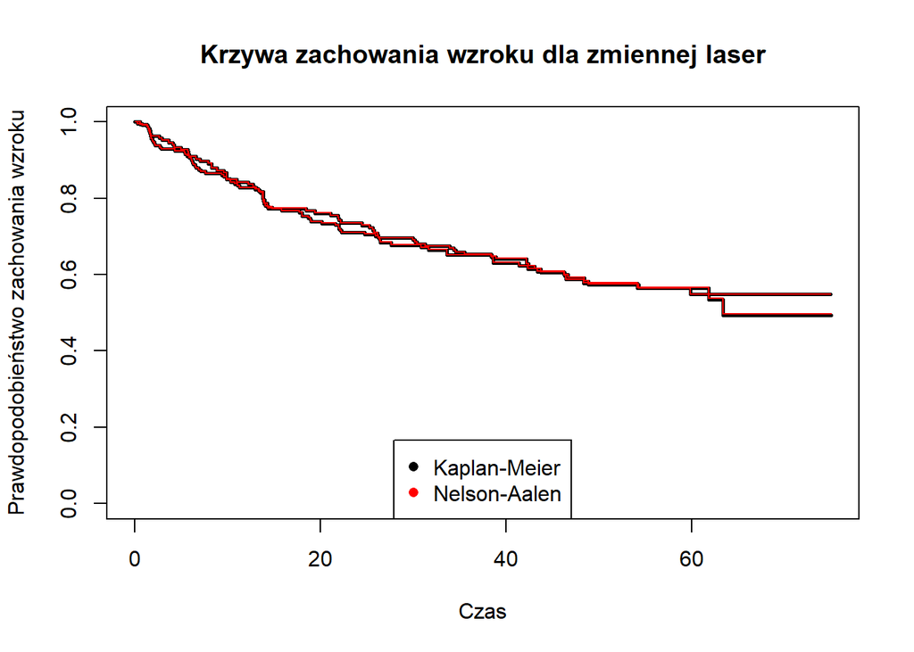

```r
mod.km.laser <- survfit(Surv(time, status) ~ laser, conf.type="plain", data=diabetic)
mod.na.laser <- survfit(Surv(time, status) ~ laser, conf.type="plain", data=diabetic, type="fleming-harrington")

plot(mod.km.laser, xlab="Czas", ylab="Prawdopodobieństwo zachowania wzroku", col = 'black',lwd = 2.5, main="Krzywa zachowania wzroku dla zmiennej laser")
lines(mod.na.laser, col="red")
legend(x = 'bottom', legend = c('Kaplan-Meier','Nelson-Aalen'), col = c('black','red'), pch=16)
```

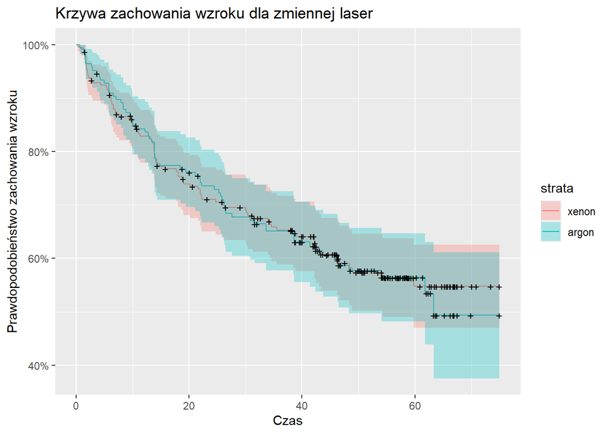

```r
autoplot(mod.km.laser, xlab="Czas", ylab="Prawdopodobieństwo zachowania wzroku", main = "Krzywa zachowania wzroku dla zmiennej laser")
```

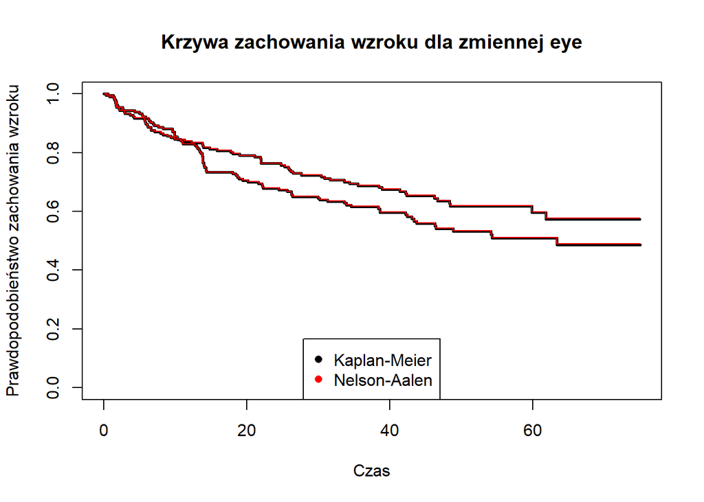

```r
mod.km.eye <- survfit(Surv(time, status) ~ eye, conf.type="plain", data=diabetic)
mod.na.eye <- survfit(Surv(time, status) ~ eye, conf.type="plain", data=diabetic, type="fleming-harrington")

plot(mod.km.eye, xlab="Czas", ylab="Prawdopodobieństwo zachowania wzroku", col = 'black',lwd = 2.5, main="Krzywa zachowania wzroku dla zmiennej eye")
lines(mod.na.eye, col="red")
legend(x = 'bottom', legend = c('Kaplan-Meier','Nelson-Aalen'), col = c('black','red'), pch=16)
```

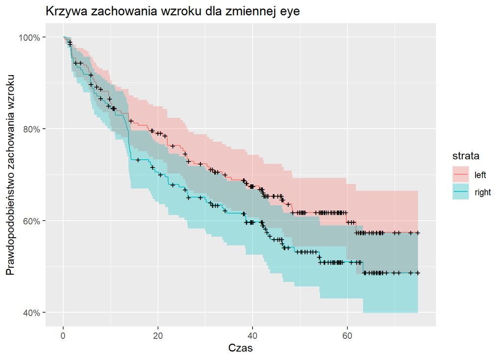

```r
autoplot(mod.km.eye, xlab="Czas", ylab="Prawdopodobieństwo zachowania wzroku", main = "Krzywa zachowania wzroku dla zmiennej eye")
```

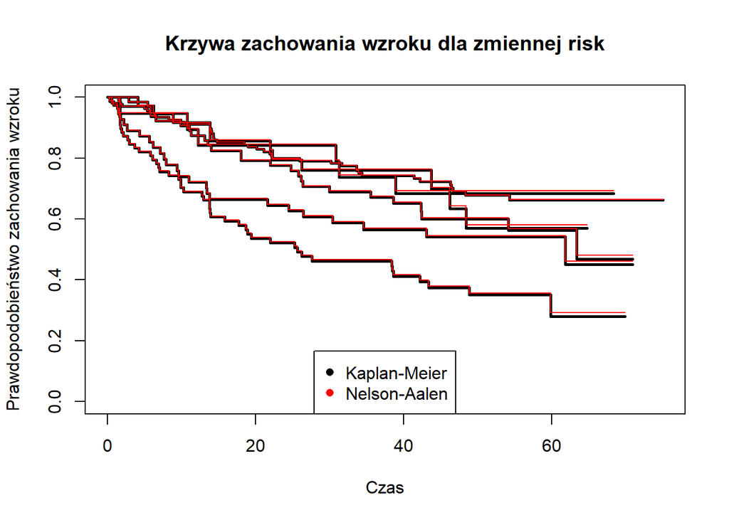

```r
mod.km.risk <- survfit(Surv(time, status) ~ risk, conf.type="plain", data=diabetic)
mod.na.risk <- survfit(Surv(time, status) ~ risk, conf.type="plain", data=diabetic, type="fleming-harrington")

plot(mod.km.risk, xlab="Czas", ylab="Prawdopodobieństwo zachowania wzroku", col = 'black',lwd = 2.5, main="Krzywa zachowania wzroku dla zmiennej risk")
lines(mod.na.risk, col="red")
legend(x = 'bottom', legend = c('Kaplan-Meier','Nelson-Aalen'), col = c('black','red'), pch=16)
```

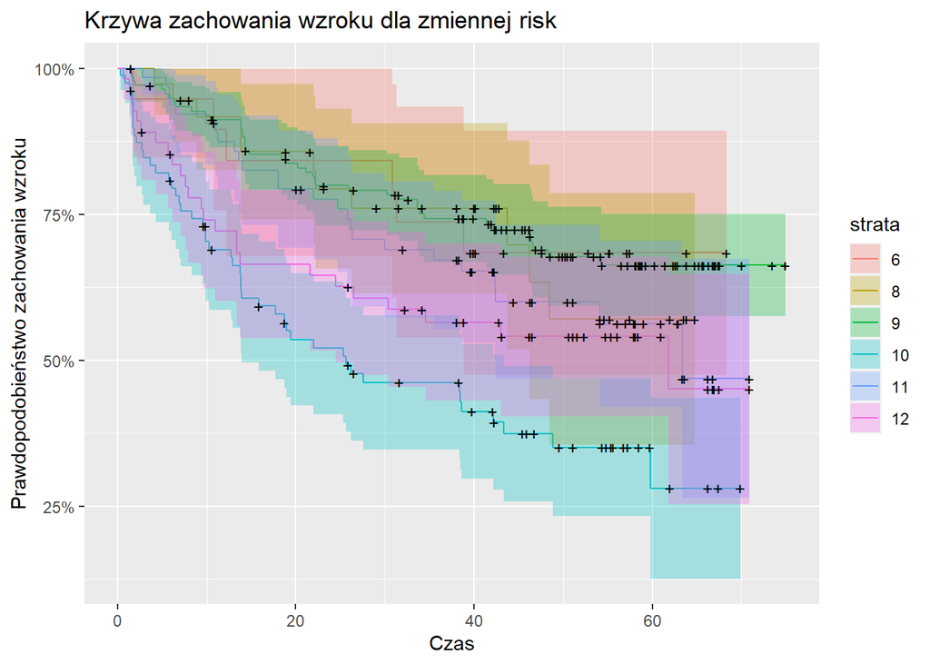

```r
autoplot(mod.km.risk, xlab="Czas", ylab="Prawdopodobieństwo zachowania wzroku", main = "Krzywa zachowania wzroku dla zmiennej risk")
```

Na wszystkich trzech powyższych wykresach również nie widać różnic między estymatorami dla grup. Dlatego też w dalszej części pracy używać będziemy estymatorów Kaplana-Meiera. Widać zauważanle różnice pomiędzy szansą na zachowanie wzroku pomiędzy prawym a lewym okiem.

# Testy krzywych przetrwania

Po wizualnej inspekcji przyszedł czas na formalne testowanie założeń. Użyte zostaną testy Peto-Peto, log-rank, modyfikacja Andersena testu Peto-Peto oraz test Fleminga-Harringtona dla różnych wag. Mamy tutaj na uwadze, że tylko jedna krzywa nie przecinała się między wariantami - krzywa dla zmiennej `trt`. Dla zmiennych `laser` oraz `eye` użyte zostaną wartości z testów Renyi a dla zmiennych `risk` i `ageCat` testy trendów, gdyż są to zmienne na skali porządkowej.

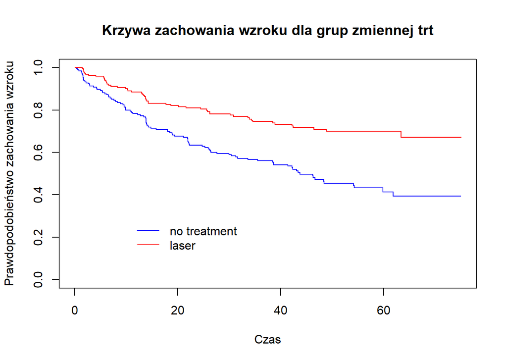

```r
km_by_trt <- survfit(Surv(time, status) ~ trt, conf.type="plain", data=diabetic)
plot(km_by_trt, col=c("blue", "red"),xlab="Czas",ylab="Prawdopodobieństwo zachowania wzroku", main="Krzywa zachowania wzroku dla grup zmiennej trt")
legend(10,0.3,c("no treatment", "laser"),lty=1, col=c("blue", "red"),bty="n")
```

```r
test=survdiff(Surv(time, status) ~ trt, data=diabetic, rho=1)
print("Wyniki testu Peto-Peto")
```

```
## [1] "Wyniki testu Peto-Peto"
```

```r
test
```

```
## Call:
## survdiff(formula = Surv(time, status) ~ trt, data = diabetic,
##     rho = 1)
##
##         N Observed Expected (O-E)^2/E (O-E)^2/V
## trt=0 197     80.3     57.6      8.95      20.7
## trt=1 197     43.1     65.8      7.84      20.7
##
##  Chisq= 20.7  on 1 degrees of freedom, p= 6e-06
```

```r
test=survdiff(Surv(time, status) ~ trt, data=diabetic, rho=0)
print("Wyniki testu log-rank")
```

```
## [1] "Wyniki testu log-rank"
```

```r
test
```

```
## Call:
## survdiff(formula = Surv(time, status) ~ trt, data = diabetic,
##     rho = 0)
##
##         N Observed Expected (O-E)^2/E (O-E)^2/V
## trt=0 197      101     71.8      11.9      22.2
## trt=1 197       54     83.2      10.3      22.2
##
##  Chisq= 22.2  on 1 degrees of freedom, p= 2e-06
```

```r
t = ten(km_by_trt)
comp(t,p=c(0,1,1,0.5,0.5),q=c(1,0,1,0.5,2))
```

```
##                          Q         Var       Z pNorm
## 1              -2.9229e+01  3.8427e+01 -4.7152     2
## n              -7.9160e+03  3.3903e+06 -4.2992     1
## sqrtN          -4.7288e+02  1.1015e+04 -4.5057     8
## S1             -2.2599e+01  2.4776e+01 -4.5403     6
## S2             -2.2507e+01  2.4600e+01 -4.5378     7
## FH_p=0_q=1     -6.5273e+00  2.1755e+00 -4.4254    10
## FH_p=1_q=0     -2.2702e+01  2.4972e+01 -4.5430     5
## FH_p=1_q=1     -4.5333e+00  1.0301e+00 -4.4665     9
## FH_p=0.5_q=0.5 -1.0818e+01  5.6398e+00 -4.5555     4
## FH_p=0.5_q=2   -1.6193e+00  1.5151e-01 -4.1603     3
##                   maxAbsZ        Var      Q pSupBr
## 1              2.9648e+01 3.8427e+01 4.7827      5
## n              7.9340e+03 3.3903e+06 4.3090      4
## sqrtN          4.7562e+02 1.1015e+04 4.5318      2
## S1             2.2822e+01 2.4776e+01 4.5850      8
## S2             2.2725e+01 2.4600e+01 4.5817      9
## FH_p=0_q=1     6.7185e+00 2.1755e+00 4.5550      1
## FH_p=1_q=0     2.2929e+01 2.4972e+01 4.5885      7
## FH_p=1_q=1     4.6371e+00 1.0301e+00 4.5689     10
## FH_p=0.5_q=0.5 1.1027e+01 5.6398e+00 4.6433      6
## FH_p=0.5_q=2   1.6837e+00 1.5151e-01 4.3257      3
```

```r
a = attr(t, "lrt")

print("Wyniki pozostałych testów")
```

```
## [1] "Wyniki pozostałych testów"
```

```r
cbind(a$W, a$pNorm)
```

```
##       [,1]             [,2]
##  [1,] "1"              "2.41459710403902e-06"
##  [2,] "n"              "1.71399829078656e-05"
##  [3,] "sqrtN"          "6.61599368467769e-06"
##  [4,] "S1"             "5.61837475343552e-06"
##  [5,] "S2"             "5.68362593877936e-06"
##  [6,] "FH_p=0_q=1"     "9.62810719795648e-06"
##  [7,] "FH_p=1_q=0"     "5.54669177588174e-06"
##  [8,] "FH_p=1_q=1"     "7.95021015109754e-06"
##  [9,] "FH_p=0.5_q=0.5" "5.22729088214824e-06"
## [10,] "FH_p=0.5_q=2"   "3.17862666647795e-05"
```

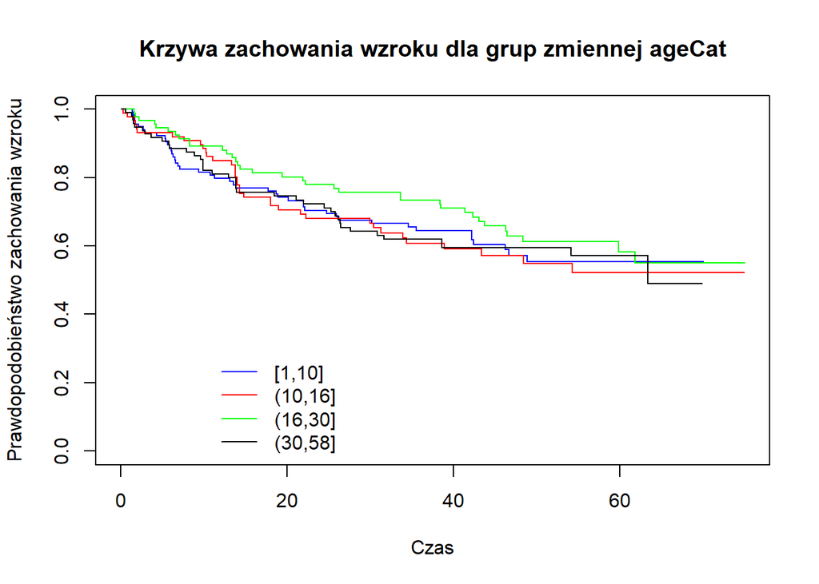

```r
km_by_ageCat <- survfit(Surv(time, status) ~ ageCat, conf.type="plain", data=diabetic)
plot(km_by_ageCat, col=c("blue", "red", "green", "black"),xlab="Czas",ylab="Prawdopodobieństwo zachowania wzroku", main="Krzywa zachowania wzroku dla grup zmiennej ageCat")
legend(10,0.3,c("[1,10]", "(10,16]", "(16,30]", "(30,58]"),lty=1, col=c("blue", "red", "green", "black"),bty="n")
```

```r
test=survdiff(Surv(time, status) ~ ageCat, data=diabetic, rho=1)
print("Wyniki testu Peto-Peto")
```

```
## [1] "Wyniki testu Peto-Peto"
```

```r
test
```

```
## Call:
## survdiff(formula = Surv(time, status) ~ ageCat, data = diabetic,
##     rho = 1)
##
##                  N Observed Expected (O-E)^2/E (O-E)^2/V
## ageCat=[1,10]  116     36.7     34.9    0.0867     0.148
## ageCat=(10,16]  90     28.6     26.7    0.1367     0.214
## ageCat=(16,30]  92     26.5     32.1    0.9815     1.648
## ageCat=(30,58]  96     31.5     29.6    0.1307     0.211
##
##  Chisq= 1.7  on 3 degrees of freedom, p= 0.6
```

```r
test=survdiff(Surv(time, status) ~ ageCat, data=diabetic, rho=0)
print("Wyniki testu log-rank")
```

```
## [1] "Wyniki testu log-rank"
```

```r
test
```

```
## Call:
## survdiff(formula = Surv(time, status) ~ ageCat, data = diabetic,
##     rho = 0)
##
##                  N Observed Expected (O-E)^2/E (O-E)^2/V
## ageCat=[1,10]  116       45     43.7    0.0388    0.0542
## ageCat=(10,16]  90       36     33.3    0.2129    0.2720
## ageCat=(16,30]  92       35     40.9    0.8641    1.1795
## ageCat=(30,58]  96       39     37.0    0.1061    0.1396
##
##  Chisq= 1.2  on 3 degrees of freedom, p= 0.7
```

```r
t = ten(km_by_ageCat)
comp(t,p=c(0,1,1,0.5,0.5),q=c(1,0,1,0.5,2))
```

```
##                  chiSq df pChisq
## 1              1.22732  3      6
## n              2.22323  3      1
## sqrtN          1.81941  3      2
## S1             1.66294  3      4
## S2             1.67026  3      3
## FH_p=0_q=1     0.43576  3      9
## FH_p=1_q=0     1.65784  3      5
## FH_p=1_q=1     0.60184  3      8
## FH_p=0.5_q=0.5 0.65171  3      7
## FH_p=0.5_q=2   0.35969  3     10
## $tft
##                          Q         Var        Z pNorm
## 1               1.9225e+00  1.9123e+02  0.13902    10
## n               1.6470e+03  1.7022e+07  0.39920     4
## sqrtN           6.5380e+01  5.5091e+04  0.27855     8
## S1              3.5091e+00  1.2402e+02  0.31510     7
## S2              3.5088e+00  1.2315e+02  0.31619     5
## FH_p=0_q=1     -1.6124e+00  1.0623e+01 -0.49470     2
## FH_p=1_q=0      3.5349e+00  1.2500e+02  0.31617     6
## FH_p=1_q=1     -9.9112e-01  5.0504e+00 -0.44102     3
## FH_p=0.5_q=0.5 -9.7419e-01  2.7806e+01 -0.18475     9
## FH_p=0.5_q=2   -5.0839e-01  7.3544e-01 -0.59281     1
##
## $scores
## [1] 1 2 3 4
```

```r
a=attr(t, 'tft')

print("Wyniki pozostałych testów")
```

```
## [1] "Wyniki pozostałych testów"
```

```r
cbind(a$tft$W, a$tft$pNorm)
```

```
##       [,1]             [,2]
##  [1,] "1"              "0.889430726959437"
##  [2,] "n"              "0.689743469071749"
##  [3,] "sqrtN"          "0.780587924433376"
##  [4,] "S1"             "0.752684537249559"
##  [5,] "S2"             "0.751859194480011"
##  [6,] "FH_p=0_q=1"     "0.620811400234464"
##  [7,] "FH_p=1_q=0"     "0.751872125934752"
##  [8,] "FH_p=1_q=1"     "0.659195355101145"
##  [9,] "FH_p=0.5_q=0.5" "0.853428413352062"
## [10,] "FH_p=0.5_q=2"   "0.553305282177656"
```

Wyniki testów oraz wygląd wykresu dla zmiennej skategoryzowanej Age wskazują, że nie występuje istotna różnica w prawdopodobieństwie zachowania wzroku jednostek w poszczególnych grupach wiekowych.

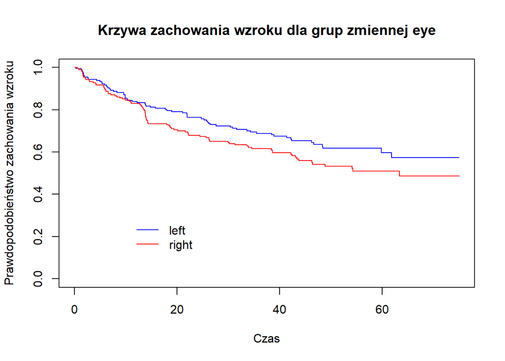

```r
km_by_eye <- survfit(Surv(time, status) ~ eye, conf.type="plain", data=diabetic)
plot(km_by_eye, col=c("blue", "red"),xlab="Czas",ylab="Prawdopodobieństwo zachowania wzroku", main="Krzywa zachowania wzroku dla grup zmiennej eye")
legend(10,0.3,c("left", "right"),lty=1, col=c("blue", "red"),bty="n")
```

```r
test=survdiff(Surv(time, status) ~ eye, data=diabetic, rho=1)
print("Wyniki testu Peto-Peto")
```

```
## [1] "Wyniki testu Peto-Peto"
```

```r
test
```

```
## Call:
## survdiff(formula = Surv(time, status) ~ eye, data = diabetic,
##     rho = 1)
##
##             N Observed Expected (O-E)^2/E (O-E)^2/V
## eye=left  197     54.8     63.3      1.15       2.9
## eye=right 197     68.5     60.0      1.21       2.9
##
##  Chisq= 2.9  on 1 degrees of freedom, p= 0.09
```

```r
test=survdiff(Surv(time, status) ~ eye, data=diabetic, rho=0)
print("Wyniki testu log-rank")
```

```
## [1] "Wyniki testu log-rank"
```

```r
test
```

```
## Call:
## survdiff(formula = Surv(time, status) ~ eye, data = diabetic,
##     rho = 0)
##
##             N Observed Expected (O-E)^2/E (O-E)^2/V
## eye=left  197       69     79.8      1.47      3.03
## eye=right 197       86     75.2      1.56      3.03
##
##  Chisq= 3  on 1 degrees of freedom, p= 0.08
```

```r
t = ten(km_by_eye)
comp(t,p=c(0,1,1,0.5,0.5),q=c(1,0,1,0.5,2))
```

```
##                         Q        Var      Z pNorm
## 1              1.0827e+01 3.8678e+01 1.7410     1
## n              3.0640e+03 3.4012e+06 1.6614     7
## sqrtN          1.8068e+02 1.1063e+04 1.7178     3
## S1             8.4824e+00 2.4886e+01 1.7004     5
## S2             8.4518e+00 2.4709e+01 1.7003     6
## FH_p=0_q=1     2.3055e+00 2.2062e+00 1.5522     9
## FH_p=1_q=0     8.5217e+00 2.5083e+01 1.7015     4
## FH_p=1_q=1     1.6822e+00 1.0422e+00 1.6477     8
## FH_p=0.5_q=0.5 4.1370e+00 5.6940e+00 1.7337     2
## FH_p=0.5_q=2   5.1751e-01 1.5420e-01 1.3179    10
##                   maxAbsZ        Var      Q pSupBr
## 1              1.1293e+01 3.8678e+01 1.8159      2
## n              3.0980e+03 3.4012e+06 1.6798      9
## sqrtN          1.8445e+02 1.1063e+04 1.7537      5
## S1             8.7474e+00 2.4886e+01 1.7535      6
## S2             8.7130e+00 2.4709e+01 1.7528      7
## FH_p=0_q=1     2.5034e+00 2.2062e+00 1.6854      8
## FH_p=1_q=0     8.7899e+00 2.5083e+01 1.7551      4
## FH_p=1_q=1     1.7962e+00 1.0422e+00 1.7595      3
## FH_p=0.5_q=0.5 4.3676e+00 5.6940e+00 1.8303      1
## FH_p=0.5_q=2   5.8122e-01 1.5420e-01 1.4801     10
```

```r
a = attr(t, "sup")

print("Wyniki pozostałych testów")
```

```
## [1] "Wyniki pozostałych testów"
```

```r
cbind(a$W, a$pSupBr)
```

```
##       [,1]             [,2]
##  [1,] "1"              "0.138769311437443"
##  [2,] "n"              "0.185975291019104"
##  [3,] "sqrtN"          "0.158974379736217"
##  [4,] "S1"             "0.159043209577826"
##  [5,] "S2"             "0.15926624184157"
##  [6,] "FH_p=0_q=1"     "0.183818657013658"
##  [7,] "FH_p=1_q=0"     "0.158494619876662"
##  [8,] "FH_p=1_q=1"     "0.156988774561625"
##  [9,] "FH_p=0.5_q=0.5" "0.134395152041818"
## [10,] "FH_p=0.5_q=2"   "0.277656043822046"
```

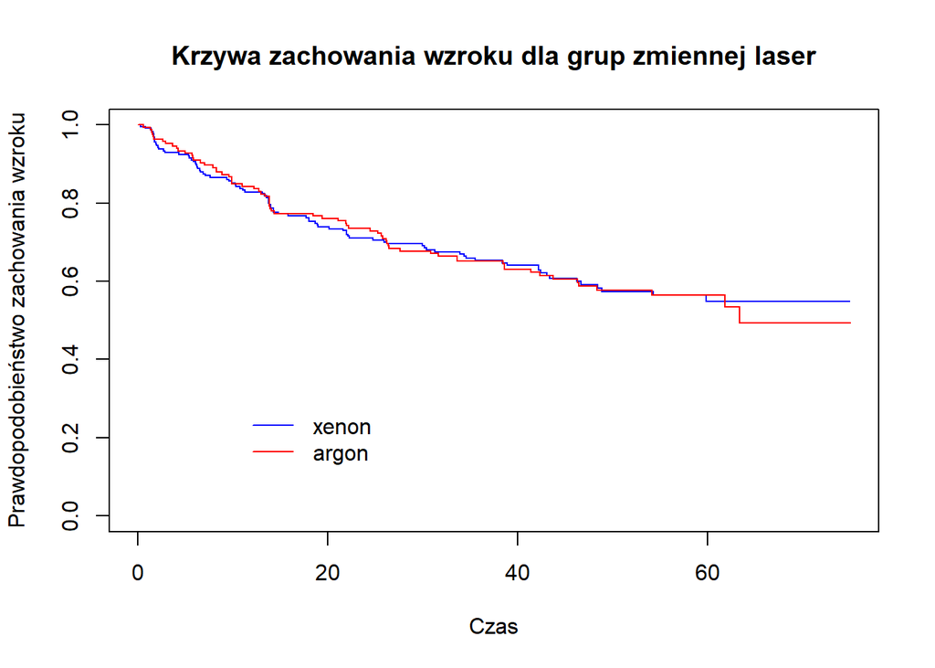

```r
km_by_laser <- survfit(Surv(time, status) ~ laser, conf.type="plain", data=diabetic)
plot(km_by_laser, col=c("blue", "red"),xlab="Czas",ylab="Prawdopodobieństwo zachowania wzroku", main="Krzywa zachowania wzroku dla grup zmiennej laser")
legend(10,0.3,c("xenon", "argon"),lty=1, col=c("blue", "red"),bty="n")
```

```r
test=survdiff(Surv(time, status) ~ laser, data=diabetic, rho=1)
print("Wyniki testu Peto-Peto")
```

```
## [1] "Wyniki testu Peto-Peto"
```

```r
test
```

```
## Call:
## survdiff(formula = Surv(time, status) ~ laser, data = diabetic,
##     rho = 1)
##
##               N Observed Expected (O-E)^2/E (O-E)^2/V
## laser=xenon 228     69.8     69.9  0.000278   0.00079
## laser=argon 166     53.5     53.4  0.000365   0.00079
##
##  Chisq= 0  on 1 degrees of freedom, p= 1
```

```r
test=survdiff(Surv(time, status) ~ laser, data=diabetic, rho=0)
print("Wyniki testu log-rank")
```

```
## [1] "Wyniki testu log-rank"
```

```r
test
```

```
## Call:
## survdiff(formula = Surv(time, status) ~ laser, data = diabetic,
##     rho = 0)
##
##               N Observed Expected (O-E)^2/E (O-E)^2/V
## laser=xenon 228       87     87.8   0.00756    0.0175
## laser=argon 166       68     67.2   0.00988    0.0175
##
##  Chisq= 0  on 1 degrees of freedom, p= 0.9
```

```r
t = ten(km_by_laser)
comp(t,p=c(0,1,1,0.5,0.5),q=c(1,0,1,0.5,2))
```

```
##                          Q         Var         Z pNorm
## 1               8.1454e-01  3.8003e+01  0.132131     5
## n              -1.0500e+02  3.3398e+06 -0.057455     6
## sqrtN           1.3075e+00  1.0871e+04  0.012541    10
## S1              1.1497e-01  2.4439e+01  0.023256     8
## S2              1.0434e-01  2.4265e+01  0.021182     9
## FH_p=0_q=1      6.7504e-01  2.1690e+00  0.458358     2
## FH_p=1_q=0      1.3950e-01  2.4632e+01  0.028108     7
## FH_p=1_q=1      4.0985e-01  1.0256e+00  0.404707     3
## FH_p=0.5_q=0.5  7.4123e-01  5.6012e+00  0.313194     4
## FH_p=0.5_q=2    2.0648e-01  1.5133e-01  0.530788     1
##                   maxAbsZ        Var       Q pSupBr
## 1              3.1318e+00 3.8003e+01 0.50802      9
## n              1.1150e+03 3.3398e+06 0.61012      1
## sqrtN          5.9078e+01 1.0871e+04 0.56662      7
## S1             2.8709e+00 2.4439e+01 0.58074      4
## S2             2.8629e+00 2.4265e+01 0.58117      3
## FH_p=0_q=1     8.5405e-01 2.1690e+00 0.57991      6
## FH_p=1_q=0     2.8786e+00 2.4632e+01 0.58001      5
## FH_p=1_q=1     5.6692e-01 1.0256e+00 0.55981      8
## FH_p=0.5_q=0.5 1.0902e+00 5.6012e+00 0.46066     10
## FH_p=0.5_q=2   2.3606e-01 1.5133e-01 0.60682      2
```

```r
a = attr(t, "sup")

print("Wyniki pozostałych testów")
```

```
## [1] "Wyniki pozostałych testów"
```

```r
cbind(a$W, a$pSupBr)
```

```
##       [,1]             [,2]
##  [1,] "1"              "0.989311433797307"
##  [2,] "n"              "0.953700215856669"
##  [3,] "sqrtN"          "0.972704798664778"
##  [4,] "S1"             "0.967173270370495"
##  [5,] "S2"             "0.966991845272748"
##  [6,] "FH_p=0_q=1"     "0.967514714742504"
##  [7,] "FH_p=1_q=0"     "0.967474075850973"
##  [8,] "FH_p=1_q=1"     "0.975154615810164"
##  [9,] "FH_p=0.5_q=0.5" "0.99619720759506"
## [10,] "FH_p=0.5_q=2"   "0.955344613174455"
```

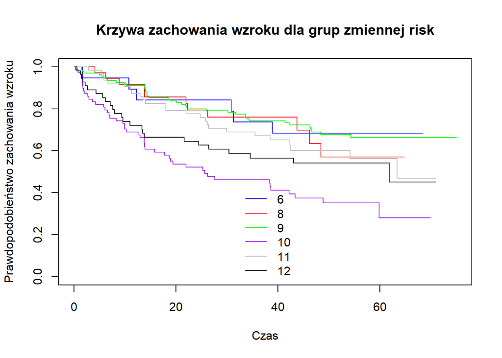

```r
km_by_risk <- survfit(Surv(time, status) ~ risk, conf.type="plain", data=diabetic)
plot(km_by_risk, col=c("blue", "red", "green"
, "purple","grey", 'black'),xlab="Czas",ylab="Prawdopodobieństwo zachowania wzroku", main="Krzywa zachowania wzroku dla grup zmiennej risk")
legend(x='bottom',0.3,c("6", "8", "9", "10", "11", "12"),lty=1, col=c("blue", "red", "green"
, "purple","grey", 'black'),bty="n")
```

```r
test=survdiff(Surv(time, status) ~ risk, data=diabetic, rho=1)
print("Wyniki testu Peto-Peto")
```

```
## [1] "Wyniki testu Peto-Peto"
```

```r
test
```

```
## Call:
## survdiff(formula = Surv(time, status) ~ risk, data = diabetic,
##     rho = 1)
##
##           N Observed Expected (O-E)^2/E (O-E)^2/V
## risk=6   20     4.65     6.82     0.692     0.911
## risk=8   37     8.27    11.83     1.070     1.445
## risk=9  139    31.51    48.46     5.931    12.097
## risk=10  79    38.93    19.42    19.592    28.168
## risk=11  64    19.01    21.03     0.193     0.285
## risk=12  55    20.94    15.75     1.709     2.404
##
##  Chisq= 35.6  on 5 degrees of freedom, p= 1e-06
```

```r
test=survdiff(Surv(time, status) ~ risk, data=diabetic, rho=0)
print("Wyniki testu log-rank")
```

```
## [1] "Wyniki testu log-rank"
```

```r
test
```

```
## Call:
## survdiff(formula = Surv(time, status) ~ risk, data = diabetic,
##     rho = 0)
##
##           N Observed Expected (O-E)^2/E (O-E)^2/V
## risk=6   20        6     8.68    0.8285    0.8791
## risk=8   37       11    14.73    0.9467    1.0480
## risk=9  139       41    61.67    6.9299   11.5767
## risk=10  79       47    23.81   22.5717   26.8303
## risk=11  64       25    26.33    0.0668    0.0806
## risk=12  55       25    19.77    1.3842    1.5887
##
##  Chisq= 33  on 5 degrees of freedom, p= 4e-06
```

```r
t = ten(km_by_risk)
comp(t,p=c(0,1,1,0.5,0.5),q=c(1,0,1,0.5,2))
```

```
##                 chiSq df pChisq
## 1              32.962  5     10
## n              35.586  5      5
## sqrtN          34.491  5      9
## S1             35.564  5      7
## S2             35.559  5      8
## FH_p=0_q=1     16.243  5      3
## FH_p=1_q=0     35.580  5      6
## FH_p=1_q=1     18.418  5      2
## FH_p=0.5_q=0.5 23.431  5      1
## FH_p=0.5_q=2   11.433  5      4
## $tft
##                         Q        Var       Z pNorm
## 1              2.9234e+01 3.0369e+02 1.67751     6
## n              9.8390e+03 2.6462e+07 1.91265     1
## sqrtN          5.3016e+02 8.6472e+04 1.80290     5
## S1             2.5854e+01 1.9413e+02 1.85558     2
## S2             2.5759e+01 1.9275e+02 1.85540     3
## FH_p=0_q=1     3.3160e+00 1.7633e+01 0.78969     9
## FH_p=1_q=0     2.5918e+01 1.9567e+02 1.85284     4
## FH_p=1_q=1     2.6900e+00 8.3182e+00 0.93271     8
## FH_p=0.5_q=0.5 8.2099e+00 4.5198e+01 1.22117     7
## FH_p=0.5_q=2   5.3635e-01 1.2338e+00 0.48287    10
##
## $scores
## [1] 1 2 3 4 5 6
```

```r
a = attr(t, "tft")

print("Wyniki pozostałych testów")
```

```
## [1] "Wyniki pozostałych testów"
```

```r
cbind(a$tft$W, a$tft$pNorm)
```

```
##       [,1]             [,2]
##  [1,] "1"              "0.0934431437430767"
##  [2,] "n"              "0.0557927708715922"
##  [3,] "sqrtN"          "0.0714046605824739"
##  [4,] "S1"             "0.0635137050102474"
##  [5,] "S2"             "0.0635386347051718"
##  [6,] "FH_p=0_q=1"     "0.429708956415875"
##  [7,] "FH_p=1_q=0"     "0.0639048719733288"
##  [8,] "FH_p=1_q=1"     "0.350971499878353"
##  [9,] "FH_p=0.5_q=0.5" "0.222021803259829"
## [10,] "FH_p=0.5_q=2"   "0.62919007903767"
```

Na podstawie wyników testów możemy stwierdzić, iż na poziomie istoności 0,05 odrzucamy hipotezę zerową mówiącą o równych sobie rozkładach prawdopodobieństwa grup na rzecz hipotezy alternatywnej. Badane przez nas grupy mają rożne rozkłady przeżycia. Zauważyć możemy, iż nakrótszy okres przeżycia będzie w grupie 10. Najdłuższy będzie w najniższej grupie ryzyka - 6.

# Model Coxa

Przejdziemy teraz do estymacji modelu Coxa, które pozwolą nam udzielić odpowiedzi na pytanie, jak bardzo dane zmienne wpływają na prawdopodobieństwo zachowania wzroku. Zanim jednak stworzymy pierwszy model, przekształcimy nieco zmienne `age` oraz `risk` w celu ułatwienia późniejszej interpretacji parametrów modelu - przekonwertujemy je na zmienne dychotomiczne. Wiek podzielimy względem mediany (dla wieku większego od mediany nowa zmienna `age_fct` przyjmie wartość 1, 0 dla niższych), a ryzyko względem wartości 10 - wartości większe lub równe 10 przyjmą wartość 1, a mniejsze 0. Wyznaczymy dla tych zmiennych również krzywe przetrwania i sprawdzimy różnicę między krzywymi w grupach za pomocą odpowiednich testów Renyi.

## Transformacje zmiennych

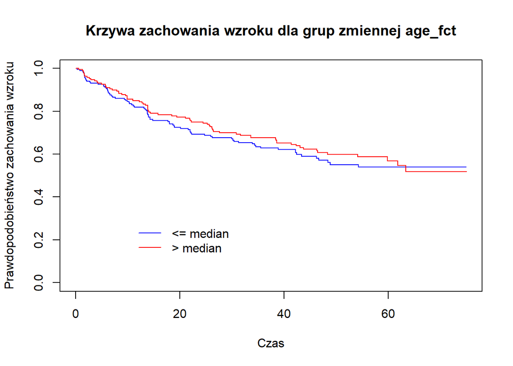

```r
diabetic$age_fct <- factor((diabetic$age>median(diabetic$age))*1)

km_by_age_fct <- survfit(Surv(time, status) ~ age_fct, conf.type="plain", data=diabetic)
plot(km_by_age_fct, col=c("blue", "red"),xlab="Czas",ylab="Prawdopodobieństwo zachowania wzroku", main="Krzywa zachowania wzroku dla grup zmiennej age_fct")
legend(10,0.3,c("<= median", "> median"),lty=1, col=c("blue", "red"),bty="n")
```

```r
test=survdiff(Surv(time, status) ~ age_fct, data=diabetic, rho=1)
print("Wyniki testu Peto-Peto")
```

```
## [1] "Wyniki testu Peto-Peto"
```

```r
test
```

```
## Call:
## survdiff(formula = Surv(time, status) ~ age_fct, data = diabetic,
##     rho = 1)
##
##             N Observed Expected (O-E)^2/E (O-E)^2/V
## age_fct=0 206     65.3     61.6     0.216     0.532
## age_fct=1 188     58.0     61.7     0.216     0.532
##
##  Chisq= 0.5  on 1 degrees of freedom, p= 0.5
```

```r
test=survdiff(Surv(time, status) ~ age_fct, data=diabetic, rho=0)
print("Wyniki testu log-rank")
```

```
## [1] "Wyniki testu log-rank"
```

```r
test
```

```
## Call:
## survdiff(formula = Surv(time, status) ~ age_fct, data = diabetic,
##     rho = 0)
##
##             N Observed Expected (O-E)^2/E (O-E)^2/V
## age_fct=0 206       81       77     0.204     0.407
## age_fct=1 188       74       78     0.202     0.407
##
##  Chisq= 0.4  on 1 degrees of freedom, p= 0.5
```

```r
t = ten(km_by_age_fct)
comp(t,p=c(0,1,1,0.5,0.5),q=c(1,0,1,0.5,2))
```

```
##                          Q         Var        Z pNorm
## 1              -3.9667e+00  3.8661e+01 -0.63795     6
## n              -1.5430e+03  3.4006e+06 -0.83674     1
## sqrtN          -8.2195e+01  1.1061e+04 -0.78154     2
## S1             -3.6590e+00  2.4878e+01 -0.73359     4
## S2             -3.6590e+00  2.4701e+01 -0.73622     3
## FH_p=0_q=1     -3.1622e-01  2.2036e+00 -0.21302     9
## FH_p=1_q=0     -3.6504e+00  2.5075e+01 -0.72899     5
## FH_p=1_q=1     -3.5048e-01  1.0414e+00 -0.34344     8
## FH_p=0.5_q=0.5 -1.1234e+00  5.6911e+00 -0.47091     7
## FH_p=0.5_q=2    6.6415e-03  1.5390e-01  0.01693    10
##                   maxAbsZ        Var       Q pSupBr
## 1              6.1369e+00 3.8661e+01 0.98698      6
## n              1.9250e+03 3.4006e+06 1.04389      1
## sqrtN          1.0846e+02 1.1061e+04 1.03126      2
## S1             5.0888e+00 2.4878e+01 1.02025      4
## S2             5.0726e+00 2.4701e+01 1.02063      3
## FH_p=0_q=1     1.0405e+00 2.2036e+00 0.70095      9
## FH_p=1_q=0     5.0964e+00 2.5075e+01 1.01774      5
## FH_p=1_q=1     8.1752e-01 1.0414e+00 0.80110      8
## FH_p=0.5_q=0.5 2.1291e+00 5.6911e+00 0.89250      7
## FH_p=0.5_q=2   2.1701e-01 1.5390e-01 0.55319     10
```

```r
a = attr(t, "sup")

print("Wyniki pozostałych testów")
```

```
## [1] "Wyniki pozostałych testów"
```

```r
cbind(a$W, a$pSupBr)
```

```
##       [,1]             [,2]
##  [1,] "1"              "0.641168411233382"
##  [2,] "n"              "0.58959568308385"
##  [3,] "sqrtN"          "0.600889665085726"
##  [4,] "S1"             "0.610805462125755"
##  [5,] "S2"             "0.610461988659213"
##  [6,] "FH_p=0_q=1"     "0.896621209760626"
##  [7,] "FH_p=1_q=0"     "0.613076749307096"
##  [8,] "FH_p=1_q=1"     "0.81377982042076"
##  [9,] "FH_p=0.5_q=0.5" "0.729435143831229"
## [10,] "FH_p=0.5_q=2"   "0.977402519046418"
```

Dla tej zmiennej, wyniki wszystkich wariantów testów (na poziomie istotności 0.05) wskazują na brak istnienia istotnej statystycznie różnicy w czasie przetrwania między wiekiem poniżej mediany a wiekiem powyżej mediany.

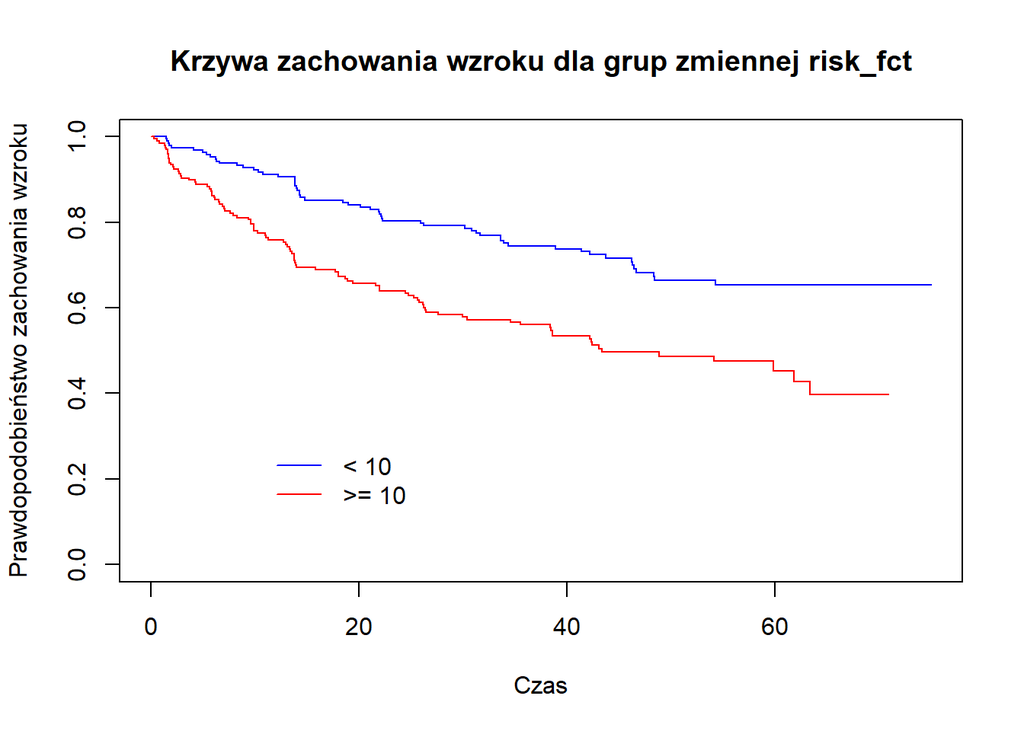

```r
diabetic$risk_fct <- factor((as.numeric(diabetic$risk)>=4)*1)

km_by_risk_fct <- survfit(Surv(time, status) ~ risk_fct, conf.type="plain", data=diabetic)
plot(km_by_risk_fct, col=c("blue", "red"),xlab="Czas",ylab="Prawdopodobieństwo zachowania wzroku", main="Krzywa zachowania wzroku dla grup zmiennej risk_fct")
legend(10,0.3,c("< 10", ">= 10"),lty=1, col=c("blue", "red"),bty="n")
```

```r
test=survdiff(Surv(time, status) ~ risk_fct, data=diabetic, rho=1)
print("Wyniki testu Peto-Peto")
```

```
## [1] "Wyniki testu Peto-Peto"
```

```r
test
```

```
## Call:
## survdiff(formula = Surv(time, status) ~ risk_fct, data = diabetic,
##     rho = 1)
##
##              N Observed Expected (O-E)^2/E (O-E)^2/V
## risk_fct=0 196     44.4     67.1      7.67      20.7
## risk_fct=1 198     78.9     56.2      9.16      20.7
##
##  Chisq= 20.7  on 1 degrees of freedom, p= 5e-06
```

```r
test=survdiff(Surv(time, status) ~ risk_fct, data=diabetic, rho=0)
print("Wyniki testu log-rank")
```

```
## [1] "Wyniki testu log-rank"
```

```r
test
```

```
## Call:
## survdiff(formula = Surv(time, status) ~ risk_fct, data = diabetic,
##     rho = 0)
##
##              N Observed Expected (O-E)^2/E (O-E)^2/V
## risk_fct=0 196       58     85.1      8.62      19.2
## risk_fct=1 198       97     69.9     10.50      19.2
##
##  Chisq= 19.2  on 1 degrees of freedom, p= 1e-05
```

```r
t = ten(km_by_risk_fct)
comp(t,p=c(0,1,1,0.5,0.5),q=c(1,0,1,0.5,2))
```

```
##                         Q        Var      Z pNorm
## 1              2.7090e+01 3.8207e+01 4.3827     5
## n              8.3000e+03 3.3779e+06 4.5160     9
## sqrtN          4.6677e+02 1.0967e+04 4.4571    10
## S1             2.2598e+01 2.4668e+01 4.5500     6
## S2             2.2511e+01 2.4493e+01 4.5486     8
## FH_p=0_q=1     4.4060e+00 2.1534e+00 3.0025     3
## FH_p=1_q=0     2.2684e+01 2.4862e+01 4.5494     7
## FH_p=1_q=1     3.2761e+00 1.0210e+00 3.2423     2
## FH_p=0.5_q=0.5 8.7879e+00 5.5957e+00 3.7150     1
## FH_p=0.5_q=2   9.3137e-01 1.4966e-01 2.4075     4
##                   maxAbsZ        Var      Q pSupBr
## 1              2.7207e+01 3.8207e+01 4.4015      6
## n              8.4990e+03 3.3779e+06 4.6243      7
## sqrtN          4.7776e+02 1.0967e+04 4.5621      5
## S1             2.2779e+01 2.4668e+01 4.5864      9
## S2             2.2705e+01 2.4493e+01 4.5877      8
## FH_p=0_q=1     4.4060e+00 2.1534e+00 3.0025      3
## FH_p=1_q=0     2.2853e+01 2.4862e+01 4.5832     10
## FH_p=1_q=1     3.2886e+00 1.0210e+00 3.2547      2
## FH_p=0.5_q=0.5 8.8294e+00 5.5957e+00 3.7325      1
## FH_p=0.5_q=2   9.3137e-01 1.4966e-01 2.4075      4
```

```r
a = attr(t, "lrt")

print("Wyniki pozostałych testów")
```

```
## [1] "Wyniki pozostałych testów"
```

```r
cbind(a$W, a$pNorm)
```

```
##       [,1]             [,2]
##  [1,] "1"              "1.17218690263154e-05"
##  [2,] "n"              "6.30083958075289e-06"
##  [3,] "sqrtN"          "8.30588988320891e-06"
##  [4,] "S1"             "5.36401106887574e-06"
##  [5,] "S2"             "5.39940092814106e-06"
##  [6,] "FH_p=0_q=1"     "0.00267773201003463"
##  [7,] "FH_p=1_q=0"     "5.3799402159882e-06"
##  [8,] "FH_p=1_q=1"     "0.00118583037577302"
##  [9,] "FH_p=0.5_q=0.5" "0.000203209456953735"
## [10,] "FH_p=0.5_q=2"   "0.0160613650897841"
```

Okazało się, że krzywe te nie przecinają się, więc wykonaliśmy warianty testu Wilcoxona. Mówią one nam, że istnieje istotna statystycznie różnica w czasie przeżycia między grupą niskiego ryzyka (poniżej 10), a grupą wysokiego ryzyka (większe bądź równe 10). Z wykresu wynika, że pacjenci w grupie podwyższonego ryzyka mieli mniejsze prawdopodobieństwo zachowania wzroku niż pacjenci w grupie niższego ryzyka.

## Estymacja pierwszego modelu

Wyestymujemy pierwszy model, do którego wejdą wszystkie zmienne (zmienne `age` i `risk` będą sfaktoryzowane). Następnie, przy użyciu funkcji stepAIC wybrana zostanie model o takich parametrach, które minimalizują wartość kryterium informacyjnego Akaike’a. W razie występowania w modelu nieistotnych statystycznie zmiennych, usuniemy je pozostawiając same istotne statystycznie predyktory.

```r
Cox=coxph(Surv(time, status)~laser+age_fct+eye+trt+risk_fct, data=diabetic)
summary(Cox)
```

```
## Call:
## coxph(formula = Surv(time, status) ~ laser + age_fct + eye +
##     trt + risk_fct, data = diabetic)
##
##   n= 394, number of events= 155
##
##               coef exp(coef) se(coef)      z Pr(>|z|)
## laserargon  0.6673    1.9491   0.4271  1.562   0.1182
## age_fct1   -0.6746    0.5093   0.4240 -1.591   0.1116
## eyeright    0.3012    1.3515   0.1628  1.850   0.0643 .
## trt1       -0.8398    0.4318   0.1698 -4.945 7.60e-07 ***
## risk_fct1   0.7329    2.0811   0.1670  4.389 1.14e-05 ***
## ---
## Signif. codes:  0 '***' 0.001 '**' 0.01 '*' 0.05 '.' 0.1 ' ' 1
##
##            exp(coef) exp(-coef) lower .95 upper .95
## laserargon    1.9491     0.5131    0.8439    4.5017
## age_fct1      0.5093     1.9633    0.2219    1.1694
## eyeright      1.3515     0.7399    0.9823    1.8594
## trt1          0.4318     2.3159    0.3095    0.6023
## risk_fct1     2.0811     0.4805    1.5002    2.8870
##
## Concordance= 0.664  (se = 0.022 )
## Likelihood ratio test= 49.89  on 5 df,   p=1e-09
## Wald test            = 47.03  on 5 df,   p=6e-09
## Score (logrank) test = 49.02  on 5 df,   p=2e-09
```

```r
library(MASS)
stepAIC(Cox,direction="backward")
```

```
## Start:  AIC=1696.08
## Surv(time, status) ~ laser + age_fct + eye + trt + risk_fct
##
##            Df    AIC
## <none>        1696.1
## - laser     1 1697.0
## - age_fct   1 1697.2
## - eye       1 1697.5
## - risk_fct  1 1714.1
## - trt       1 1720.0
```

```
## Call:
## coxph(formula = Surv(time, status) ~ laser + age_fct + eye +
##     trt + risk_fct, data = diabetic)
##
##               coef exp(coef) se(coef)      z        p
## laserargon  0.6673    1.9491   0.4271  1.562   0.1182
## age_fct1   -0.6746    0.5093   0.4240 -1.591   0.1116
## eyeright    0.3012    1.3515   0.1628  1.850   0.0643
## trt1       -0.8398    0.4318   0.1698 -4.945 7.60e-07
## risk_fct1   0.7329    2.0811   0.1670  4.389 1.14e-05
##
## Likelihood ratio test=49.89  on 5 df, p=1.46e-09
## n= 394, number of events= 155
```

Po zastosowaniu minimalizowania kryterium AIC okazało się, że wybrany został model początkowy. Zawiera on jednak trzy nieistotne statystycznie zmienne (a raczej nieistotne statystycznie różnice między poziomami zmiennych) `age_fct`, `eye` oraz `laser`. Usuniemy te zmienne z modelu.

```r
Cox=coxph(Surv(time, status) ~ risk_fct + trt, data=diabetic)
summary(Cox)
```

```
## Call:
## coxph(formula = Surv(time, status) ~ risk_fct + trt, data = diabetic)
##
##   n= 394, number of events= 155
##
##              coef exp(coef) se(coef)      z Pr(>|z|)
## risk_fct1  0.7402    2.0963   0.1665  4.445 8.80e-06 ***
## trt1      -0.8011    0.4488   0.1690 -4.741 2.12e-06 ***
## ---
## Signif. codes:  0 '***' 0.001 '**' 0.01 '*' 0.05 '.' 0.1 ' ' 1
##
##           exp(coef) exp(-coef) lower .95 upper .95
## risk_fct1    2.0963      0.477    1.5125     2.905
## trt1         0.4488      2.228    0.3223     0.625
##
## Concordance= 0.637  (se = 0.022 )
## Likelihood ratio test= 42.94  on 2 df,   p=5e-10
## Wald test            = 40.94  on 2 df,   p=1e-09
## Score (logrank) test = 42.81  on 2 df,   p=5e-10
```

Powyżej znajdują się wyestymowane parametry modelu Coxa z dwoma istotnymi predyktorami. Zanim przejdziemy do interpretacji parametrów, sprawdzimy założenie o proporcjonalności oraz usuniemy wartości odstające.

Weryfikacja założenia o proporcjonalności, H0 - hazard jest proporcjonalny dla danej zmiennej w czasie, na wykresach linia chyba musi być w miarę prosta (wykres liniowy albo stały)

```r
Prop=cox.zph(Cox,transform="identity")
print(Prop)
```

```
##          chisq df    p
## risk_fct 0.908  1 0.34
## trt      0.985  1 0.32
## GLOBAL   1.768  2 0.41
```

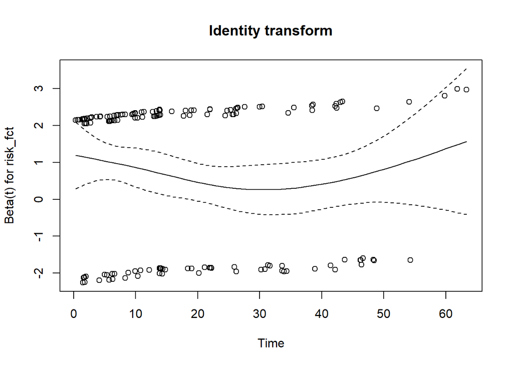

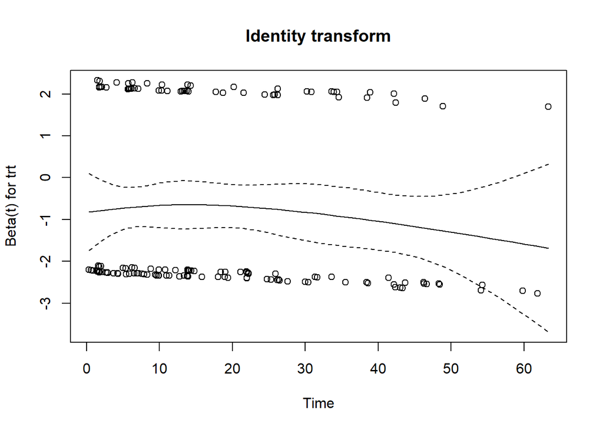

```r
plot(Prop, main = "Identity transform")
```

```r
Prop=cox.zph(Cox,transform="rank")
print(Prop)
```

```
##          chisq df    p
## risk_fct  1.11  1 0.29
## trt       1.07  1 0.30
## GLOBAL    2.03  2 0.36
```

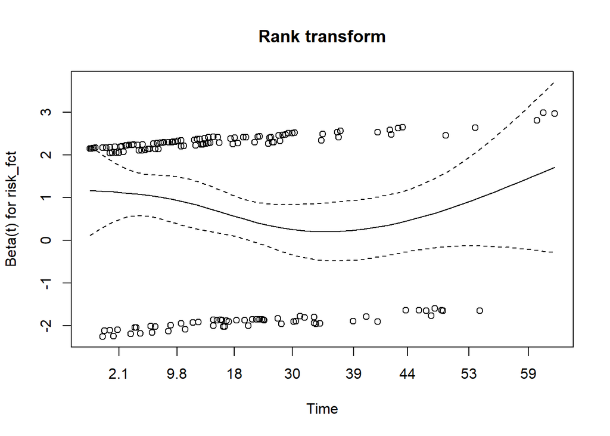

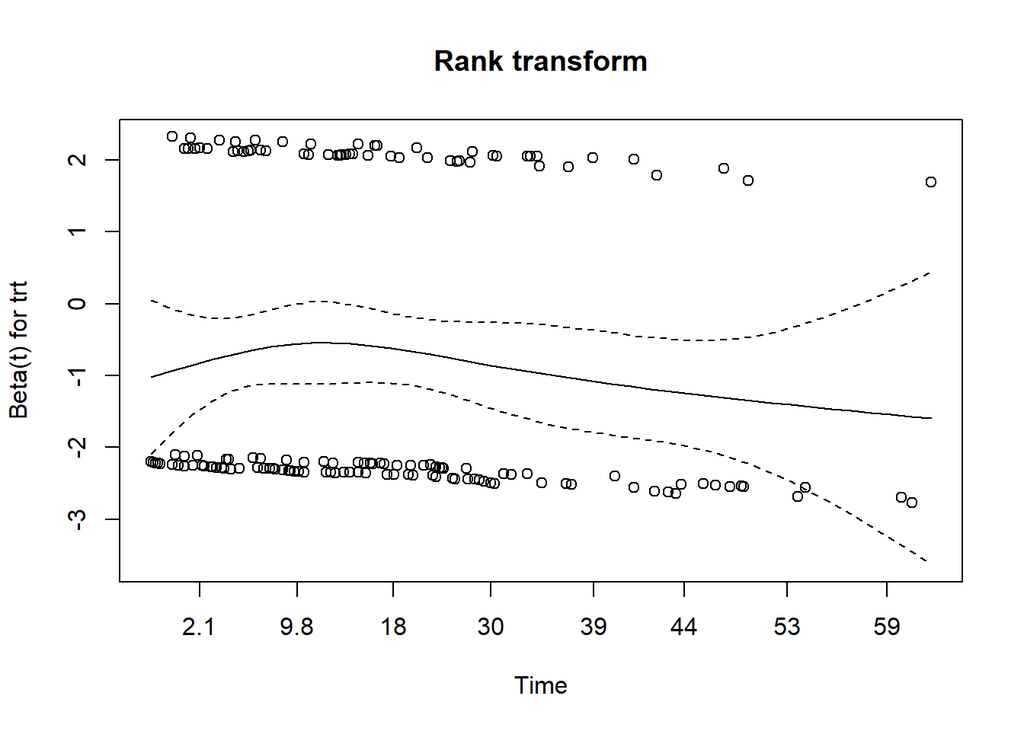

```r
plot(Prop, main = "Rank transform")
```

```r
Prop=cox.zph(Cox,transform="km")
print(Prop)
```

```
##          chisq df    p
## risk_fct 2.063  1 0.15
## trt      0.665  1 0.41
## GLOBAL   2.622  2 0.27
```

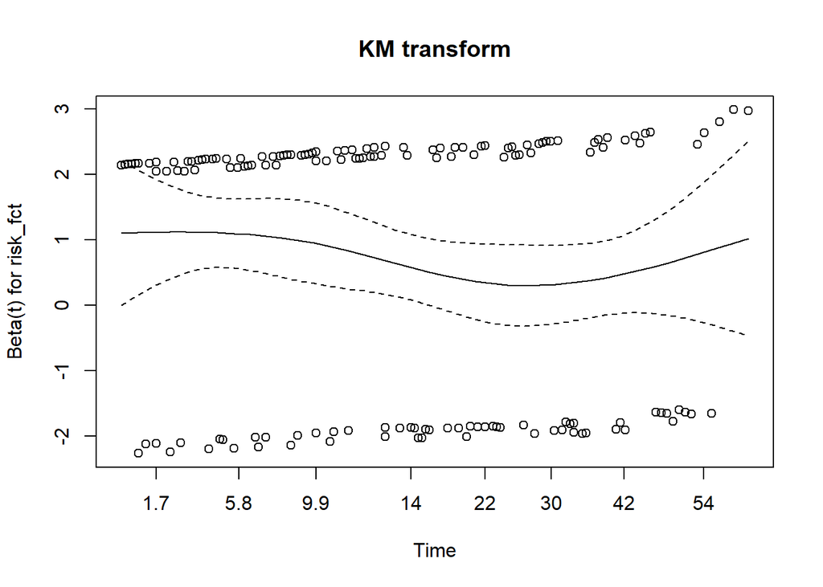

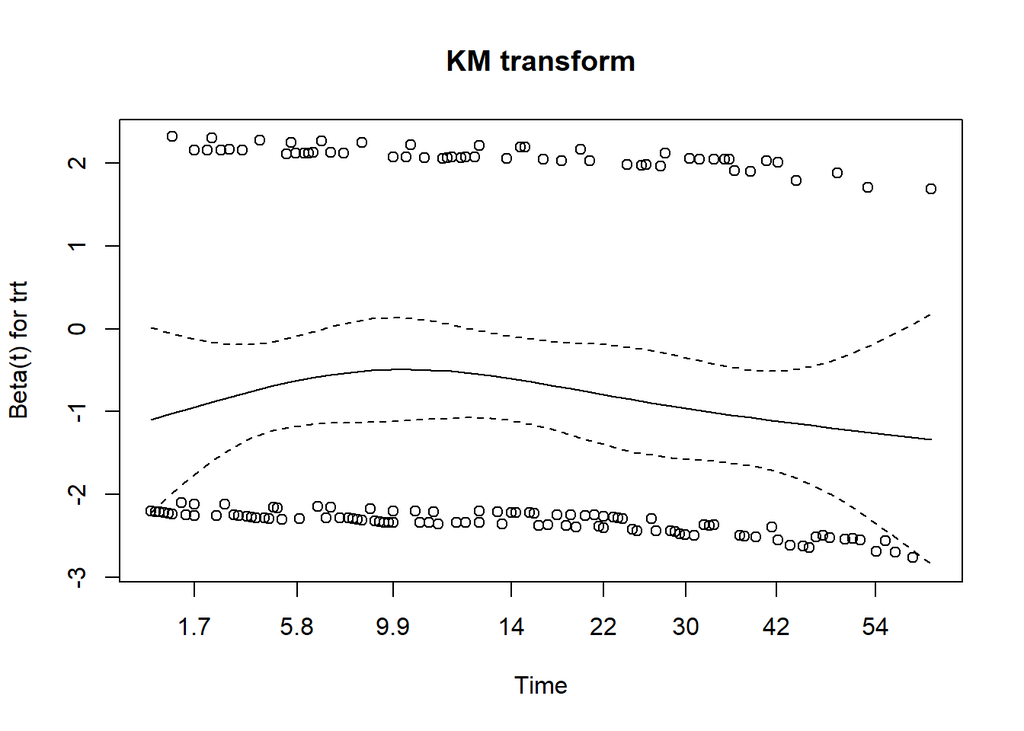

```r
plot(Prop, main = "KM transform")
```

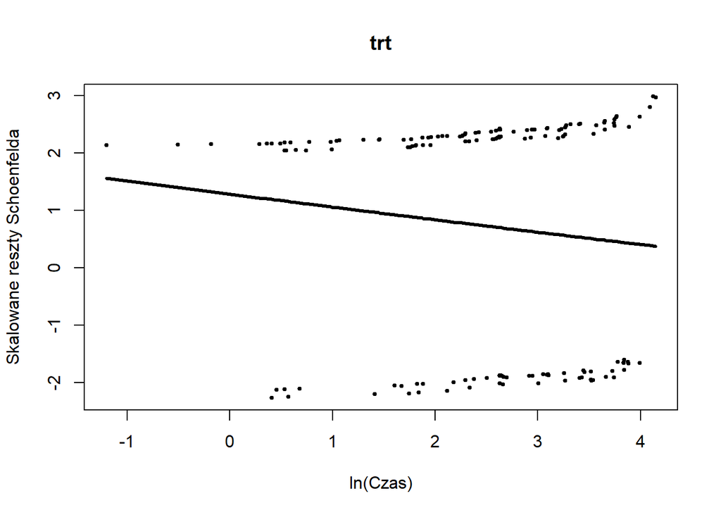

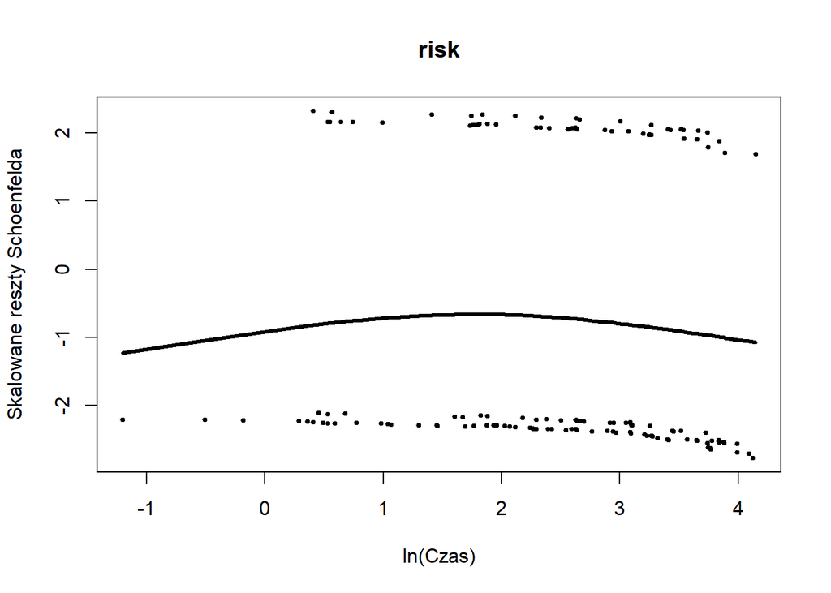

```r
reszty=resid(Cox, type="scaledsch")
Time=as.numeric(rownames(reszty))
zmienne=c('trt','risk')
for (i in 1:2)
{plot(log(Time), reszty[,i], xlab="ln(Czas)",main=zmienne[i],
      ylab="Skalowane reszty Schoenfelda",pch=20, cex=0.7)
  lines( smooth.spline(log(Time), reszty[,i] ), lwd=3 )
}
```

Z powyższych testów wynika, że dla wszystkich wariantów transformacji czasów przetrwania, funkcja skumulowanego hazardu jest proporcjonalna dla zmiennych w czasie. Wykresy skalowanych reszt Schoenfelda (W różnych wariantach transformacji czasu przeżycia) potwierdzają ten fakt. Przystąpimy teraz do wyrzucenia ze zbioru wartości odstających, wyliczonych na podstawie reszt z wyestymowanego wcześniej modelu. Posłużymy się tutaj odchyleniami standardowymi od wartości pradziwych oraz statystyką dfbeta, która służy do wykrywania wpływowych obserwacji.

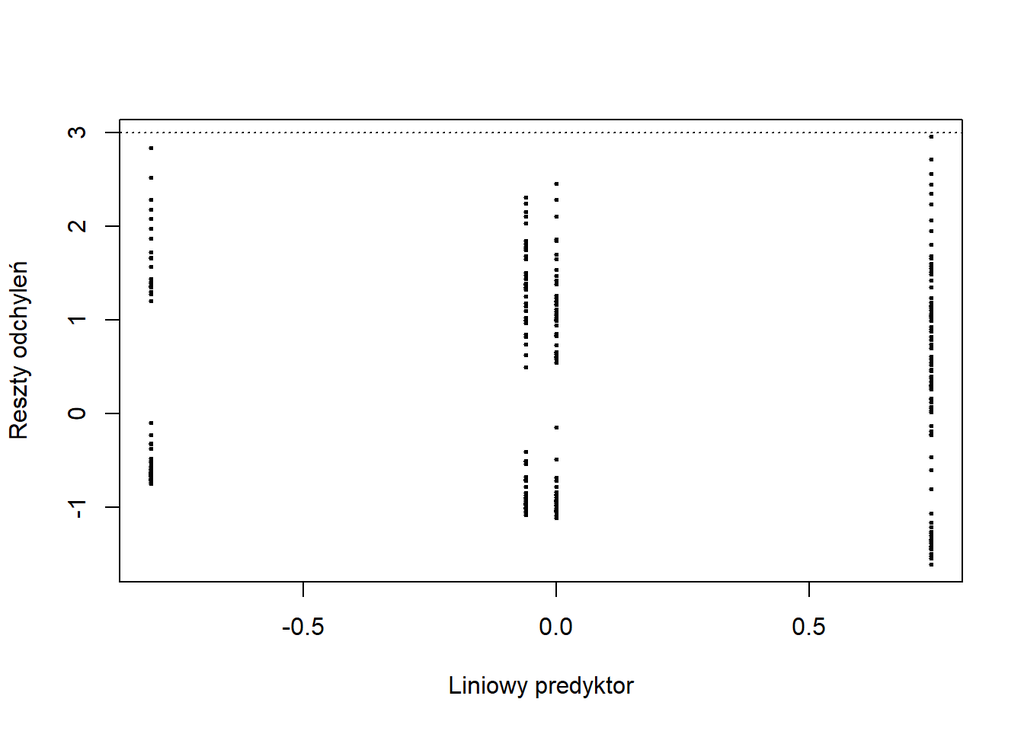

```r
deviance <- residuals(Cox,type="deviance")
lin.pred <- Cox$linear.predictors
plot(lin.pred, deviance, xlab="Liniowy predyktor", ylab="Reszty odchyleń", cex=0.5, pch=20)
abline(h=3,lty=3)
```

```r
diabetic$deviance <- deviance
to.del.1 <- which(diabetic$deviance>3)
```

Okazuje się, że w naszym modelu żadne reszty obserwacji nie przekraczają 3 odchyleń standardowych, więc pozostawiliśmy wszystkie obserwacje. Następnie przejdziemy do usuwania obserwacji przy pomocy statystyki dfbeta. Wartość graniczną przyrostu oceny parametru ustaliliśmy tutaj na wartość bezwzględną z 0.01 dla obu zmiennych.

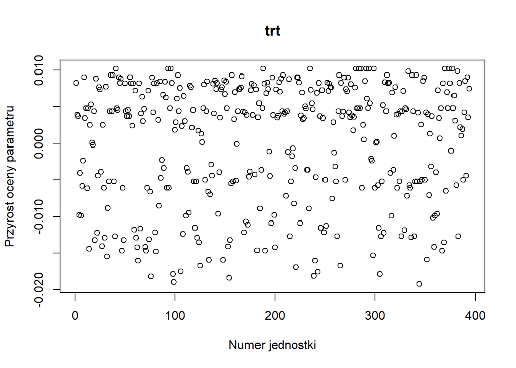

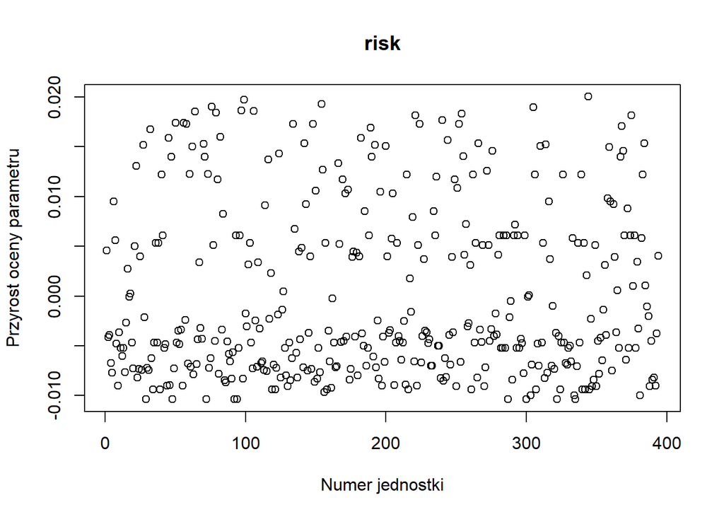

```r
df.beta <- residuals(Cox,type="dfbeta")
n <- dim(df.beta)[1]
obs.nr <- c(1:n)
for (j in 1:2) {
  plot(obs.nr, df.beta[,j], xlab="Numer jednostki", ylab="Przyrost oceny parametru", main=zmienne[j])
}
```

```r
to.del.2 <- which(abs(df.beta[,1]) > (0.01))
to.del.3 <- which(abs(df.beta[,2])>(0.01))
```

Bazując na tym kryterium, usuniętych zostało 121 obserwacji. Jesteśmy więc już gotowi na estymację ostatecznego modelu i interpretację jego parametrów.

```r
c <- sort(unique(c(to.del.1, to.del.2, to.del.3)))
diabetic.red <- diabetic[-c,]
Cox2 <- coxph(Surv(time, status) ~ trt + risk_fct, data=diabetic.red)
summary(Cox2)
```

```
## Call:
## coxph(formula = Surv(time, status) ~ trt + risk_fct, data = diabetic.red)
##
##   n= 273, number of events= 77
##
##               coef exp(coef) se(coef)      z Pr(>|z|)
## trt1      -4.38074   0.01252  0.72362 -6.054 1.41e-09 ***
## risk_fct1  2.51859  12.41111  0.34268  7.350 1.99e-13 ***
## ---
## Signif. codes:  0 '***' 0.001 '**' 0.01 '*' 0.05 '.' 0.1 ' ' 1
##
##           exp(coef) exp(-coef) lower .95 upper .95
## trt1        0.01252   79.89740  0.003031   0.05169
## risk_fct1  12.41111    0.08057  6.340490  24.29395
##
## Concordance= 0.886  (se = 0.011 )
## Likelihood ratio test= 205.3  on 2 df,   p=<2e-16
## Wald test            = 86.57  on 2 df,   p=<2e-16
## Score (logrank) test = 176.7  on 2 df,   p=<2e-16
```

Ujemny współczynnik dla zmiennej `trt` przy wariancie 1 oznacza, że poddanie się terapii redukuje hazard (czyli ryzyko utraty wzroku) o 99% w stosunku do nie poddawania się terapii, przy niezmienionej grupie ryzyka. Współczynnik przy zmiennej `risk_fct` oznacza, że bycie w grupie wysokiego ryzyka zwiększa hazard (czyli ryzyko utraty wzroku) o 1140% w stosunku do grupy niższego ryzyka, przy niezmienionej wartości zmiennej `trt`.

```r
Prop=cox.zph(Cox2,transform="identity")
print(Prop)
```

```
##          chisq df     p
## trt      0.953  1 0.329
## risk_fct 3.848  1 0.050
## GLOBAL   4.877  2 0.087
```

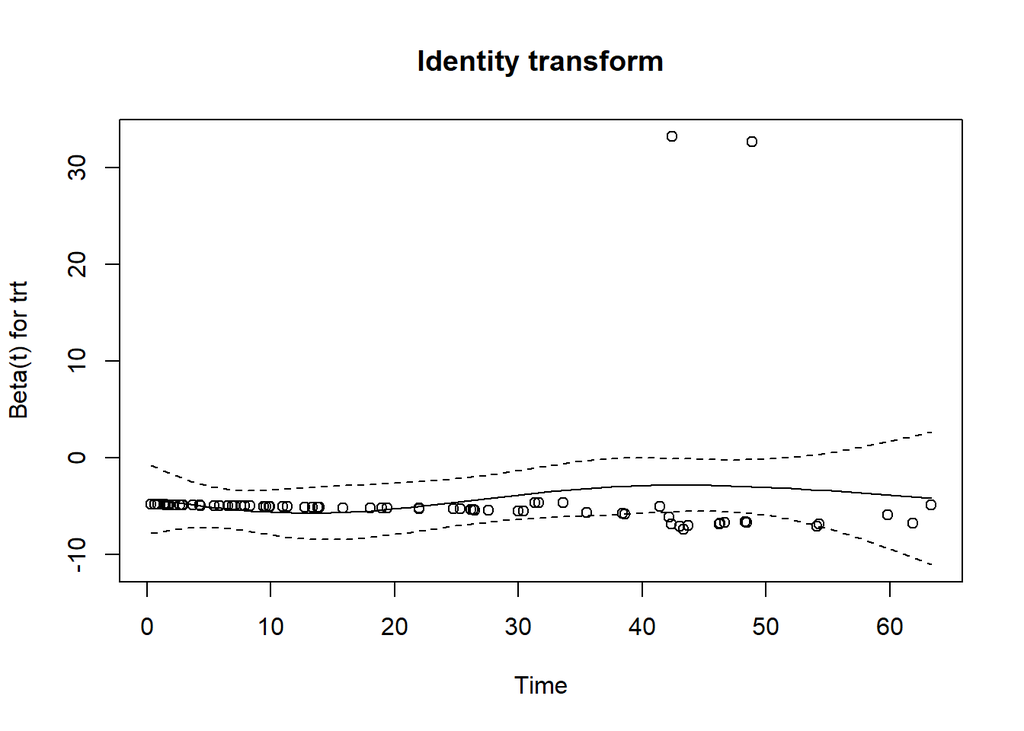

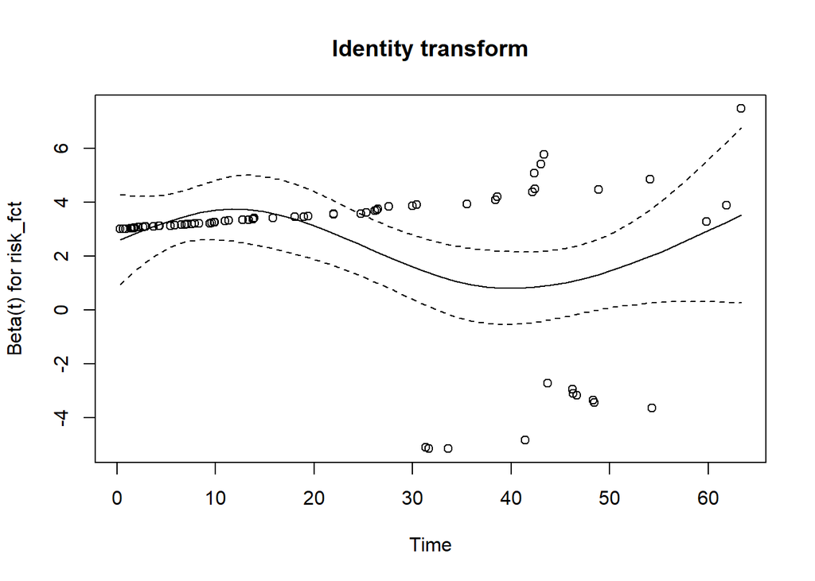

```r
plot(Prop, main = "Identity transform")
```

```r
Prop=cox.zph(Cox2,transform="rank")
print(Prop)
```

```
##          chisq df     p
## trt      0.996  1 0.318
## risk_fct 2.934  1 0.087
## GLOBAL   4.006  2 0.135
```

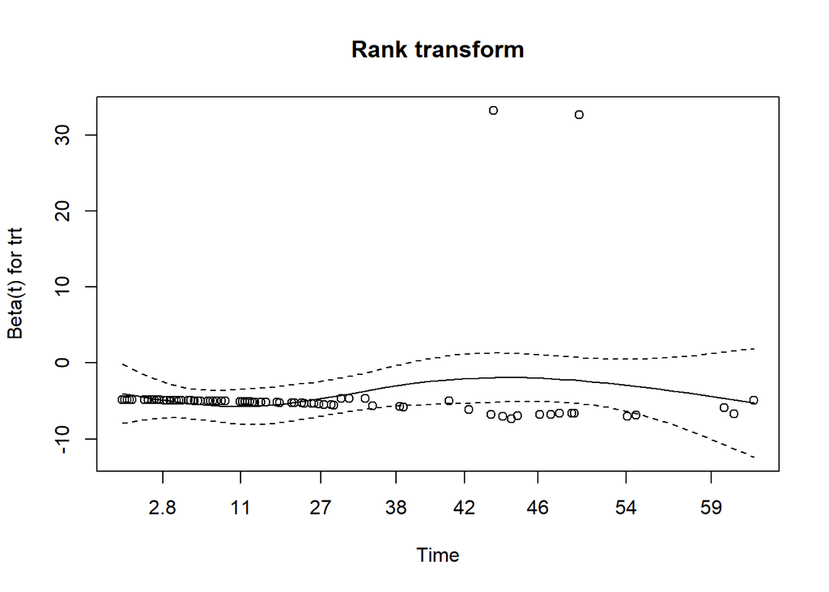

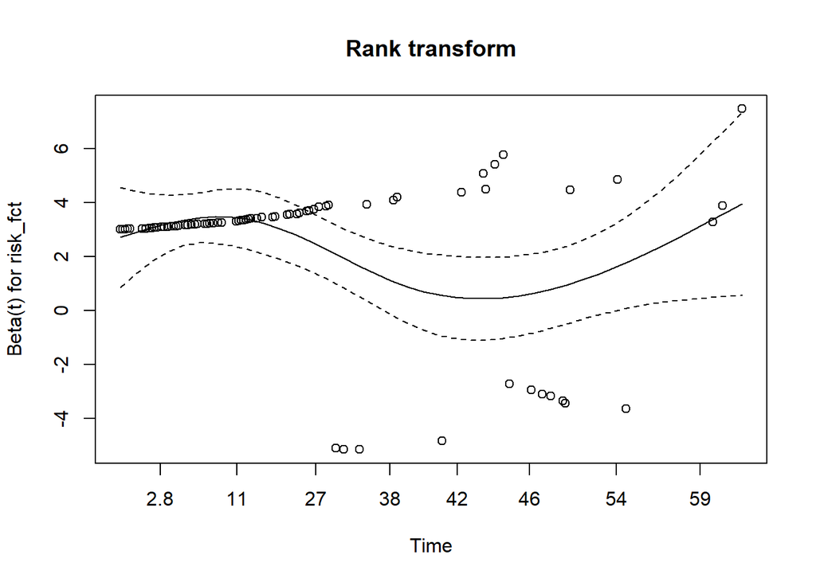

```r
plot(Prop, main = "Rank transform")
```

```r
Prop=cox.zph(Cox2,transform="km")
print(Prop)
```

```
##          chisq df     p
## trt       1.06  1 0.303
## risk_fct  3.67  1 0.055
## GLOBAL    4.82  2 0.090
```

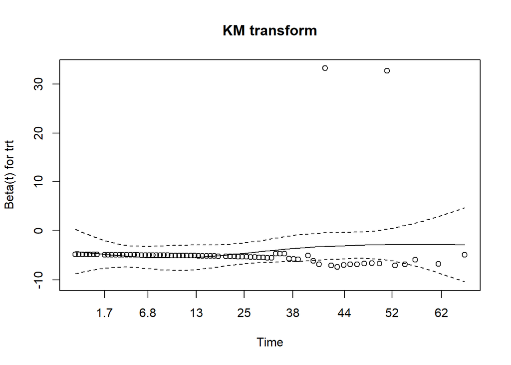

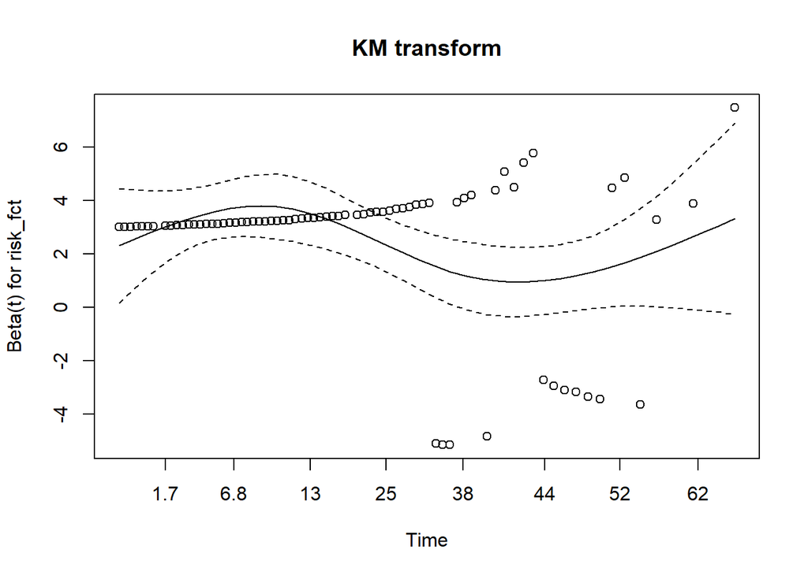

```r
plot(Prop, main = "KM transform")
```

Jak widać powyżej - założenia dla tego modelu również zostały spełnione, mimo faktu, że znajdujemy się bardzo blisko granicy poziomu istotności dla zmiennej `risk_fct`.

Podsumowując całą pracę - na podstawie danych wejściowych udało nam się stwierdzić, że poddanie się terapii zwiększa szansę na zachowanie wzroku w stosunku do grupy nie poddającej się terapii, a grupa wysokiego ryzyka cechuje się bardzo wielką dysproporcją w szansach na zachowanie wzroku - na korzyść grupy mniejszego ryzyka.